# PNS 2019 Analysis

Mário O. de Menezes

12/07/2021

```r
library(survey)
library(srvyr)
library(ggplot2)
library(ggpubr)
library(tidyverse)
library(dplyr)
library(knitr)
library(tidyr)
library(janitor)
library(pander)
library(crosstable)
library(jtools)
library(flextable)
library(gt)
library(gtsummary)
library(gtExtras)
library(rio)
```

# PNS 2019

## Using the new PNS 2019 - IBGE com PNSIBGE pkg

```r
# usando a biblioteca rio
pns2019.1 <- import("data/PNSIBGE_Rpkg/pns2019microdata_get_pns20230505.csv")
```

```r
#load("~/datasets/IBGE/PNS/2019/pns2019_dwnld20210923.rdata")
#pns2019 <- readRDS("~/datasets/IBGE/PNS/PNSIBGE_Rpkg/pns2019microdata_dnld20221122.RDS")

pns2019.1 <- pns2019.1 %>%
  filter(V0025A=="1") %>%
  filter(!is.na(V0029))

#Estados - UFs
#pns2019.1 <- pns2019.1 %>% rename(UF=V0001)
pns2019.1 <- mutate(pns2019.1, UF = factor(V0001, levels=c(11,12,13,14,15,16,17,21,22,23,24,25,26,27,28,29,31,32,33,35,41,42,43,50,51,52,53), label=c("Rondonia","Acre","Amazonas","Roraima","Para","Amapa","Tocantins","Maranhao","Piaui","Ceara",
                                        "Rio Grande do Norte","Paraiba","Pernambuco","Alagoas","Sergipe","Bahia",
                                        "Minas Gerais","Espirito Santo","Rio de Janeiro","Sao Paulo",
                                        "Parana","Santa Catarina","Rio Grande do Sul",
                                        "Mato Grosso do Sul","Mato Grosso","Goias","Distrito Federal")))
#Grandes Regiões
pns2019.1 <- pns2019.1 %>%
  mutate(Regiao = fct_collapse(UF,
                `Norte` = c("Rondonia","Acre","Amazonas","Roraima","Para", "Amapa","Tocantins"),
                `Nordeste` = c("Maranhao", "Piaui", "Ceara", "Rio Grande do Norte", "Paraiba","Pernambuco", "Alagoas","Sergipe","Bahia"),
                `Sudeste` = c("Minas Gerais", "Espirito Santo","Rio de Janeiro", "Sao Paulo"),
                `Sul` = c("Parana", "Santa Catarina", "Rio Grande do Sul"),
                `Centro-Oeste`= c("Mato Grosso do Sul","Mato Grosso", "Goias", "Distrito Federal")))
#Capital
pns2019.1<- pns2019.1 %>% mutate(Capital= fct_collapse(UF,
                                        `Porto Velho`= "Rondonia",
                                        `Boa Vista`= "Roraima",
                                        `Rio Branco `= "Acre",
                                        `Manaus` = "Amazonas",
                                        `Boa Vista`= "Roraima",
                                        `Belem` = "Para" ,
                                        `Macapa`= "Amapa",
                                        `Palmas` = "Tocantins",
                                        `Sao Luis` = "Maranhao",
                                        `Teresina`= "Piaui" ,
                                        `Fortaleza`= "Ceara",
                                        `Natal`= "Rio Grande do Norte",
                                        `Joao Pessoa`= "Paraiba",
                                        `Recife`= "Pernambuco",
                                        `Maceio`= "Alagoas",
                                        `Aracaju`= "Sergipe",
                                        `Salvador`= "Bahia",
                                        `Belo Horizonte`= "Minas Gerais",
                                        `Vitoria`= "Espirito Santo",
                                        `Rio de Janeiro`= "Rio de Janeiro",
                                        `Sao Paulo`= "Sao Paulo",
                                        `Curitiba`= "Parana",
                                        `Florianopolis`= "Santa Catarina",
                                        `Porto Alegre`= "Rio Grande do Sul",
                                        `Campo Grande`=  "Mato Grosso do Sul",
                                        `Cuiaba`= "Mato Grosso",
                                        `Goiania` = "Goias",
                                        `Brasilia`= "Distrito Federal"))
# copiei os indicadores da Fiocruz para comparar os resultados

#Q001P - Pressão arterial nunca aferida
pns2019.1 <- pns2019.1 %>% mutate(Q001P = ifelse(Q00101 == 6,1,2))
pns2019.1 <- pns2019.1 %>% mutate(Q001P = factor(Q001P, levels=c(1,2), labels=c("Sim","Não")))

#Q003P - Exame de sangue para medir a glicemia nunca realizado
pns2019.1 <- pns2019.1 %>% mutate(Q003P = ifelse(Q02901 == 6,1,2))
pns2019.1 <- pns2019.1 %>% mutate(Q003P = factor(Q003P, levels=c(1,2), labels=c("Sim","Não")))

# diabetes
pns2019.1 <- pns2019.1 %>% mutate(Q004P = if_else(Q03002==1 & C006==2,2,
                                          if_else(Q03001==1,1,2,missing=2),missing=2))
pns2019.1 <- pns2019.1 %>% mutate(Q004P = factor(Q004P, levels=c(1,2), labels=c("Sim","Não")))

pns2019.1 <- rename_with(pns2019.1,tolower)
pns2019.1 <- pns2019.1 %>% mutate(one = 1)

pns2019.1 <- pns2019.1 %>%
  mutate(w00103 = as.numeric(w00103), w00203 = as.numeric(w00203),
         p00104 = as.numeric(p00104), p00404 = as.numeric(p00404)) %>%
   mutate(imc = w00103/(w00203/100*w00203/100))
# só moradores com 18 anos ou mais - consistente com a PNS 2013
#pns_design_srvyr <-subset(pns_design_srvyr, c008 >= 18)
# as variaveis w00103 e w00203 (peso e altura medidos) estão com muitos NAs.
# vou utilizar o peso e altura informado pelo participante para os calculos
pns2019.1 <- pns2019.1 %>%
  #filter(!is.na(p00104), !is.na(p00404)) %>%
  mutate(imci = p00104/(p00404/100*p00404/100))
```

```r
pns2019.1 <- pns2019.1%>%
   mutate(imcclass = case_when(imc < 17.0 ~ "1",
                               imc >= 17.0 & imc < 18.5 ~ "2",
                               imc >= 18.5 & imc < 25.0 ~ "3",
                               imc >= 25.0 & imc < 30.0 ~ "4",
                               imc >= 30.0 & imc < 35.0 ~ "5",
                               imc >= 35.0 & imc < 40.0 ~ "6",
                               imc >= 40.0 ~ "7",
                               TRUE ~ "Nenhum"
        ))

pns2019.1 <- pns2019.1 %>%
   mutate(imcclassi = case_when(imci < 17.0 ~ "1",
                               imci >= 17.0 & imci < 18.5 ~ "2",
                               imci >= 18.5 & imci < 25.0 ~ "3",
                               imci >= 25.0 & imci < 30.0 ~ "4",
                               imci >= 30.0 & imci < 35.0 ~ "5",
                               imci >= 35.0 & imci < 40.0 ~ "6",
                               imci >= 40.0 ~ "7",
                               TRUE ~ "Nenhum"
        )) %>%
  mutate(imcclass2 = case_when(imci < 25 ~ "Low/Normal (<25)",
                               imci >= 25.0 & imci < 30.0 ~ "Overweight (25-29.9)",
                               imci >= 30.0 ~ "Obesity (>30)",
                               TRUE ~ "Missing Data"
        ))

pns2019.1 <- pns2019.1 %>% mutate(imcclass2 = ordered(imcclass2,
                               levels = c("Low/Normal (<25)", "Overweight (25-29.9)", "Obesity (>30)", "Missing Data")))

pns2019.1 <- pns2019.1 %>% mutate(idade = as.numeric(c008))
pns2019.1 <- pns2019.1 %>%
     mutate(fxetaria = case_when(idade <   5.0 ~ "2",
                                 idade >=  5.0 & idade < 10.0 ~ "7",
                                 idade >= 10.0 & idade < 15.0 ~ "12",
                                 idade >= 15.0 & idade < 20.0 ~ "18",
                                 idade >= 20.0 & idade < 25.0 ~ "22",
                                 idade >= 25.0 & idade < 40.0 ~ "32",
                                 idade >= 40.0 & idade < 60.0 ~ "50",
                                 idade >= 60.0 ~ "60"))
pns2019.1 <- pns2019.1 %>%
     mutate(fxetaria2 = case_when(idade < 18.0 ~ "<18",
                                  idade >= 18.0 & idade < 25.0 ~ "18-24",
                                  idade >= 25.0 & idade < 35.0 ~ "25-34",
                                  idade >= 35.0 & idade < 45.0 ~ "35-44",
                                  idade >= 45.0 & idade < 55.0 ~ "45-54",
                                  idade >= 55.0 & idade < 65.0 ~ "55-64",
                                  idade >= 65.0 ~ "65+")) %>%
     mutate(age = cut(idade,breaks = c(-0.01,17.9,24.9,34.9,44.9,54.9,64.9,Inf),
                      labels = c("<18","18-24","25-34","35-44","45-54","55-64","65+")))

# faixas do IBGE na publicação PNS 2019
#De 18 a 29 anos
#De 30 a 59 anos
#De 60 a 64 anos
#De 65 a 74 anos
#De 75 anos ou mais
pns2019.1 <- pns2019.1 %>%
  mutate(fxetaria3 = case_when(idade < 18.0 ~ "<18",
                               idade >= 18.0 & idade < 30.0 ~ "18-29",
                               idade >= 30.0 & idade < 60.0 ~ "30-59",
                               idade >= 60.0 & idade < 65.0 ~ "60-64",
                               idade >= 65.0 & idade < 75.0 ~ "65-74",
                               idade >= 75.0 ~ "75+"))

pns2019.1 <- pns2019.1 %>% mutate(fxetaria = ordered(fxetaria,
            levels = c("2","7","12","18","22","32","50","60")))
pns2019.1 <- pns2019.1 %>% mutate(fxetaria2  = ordered(fxetaria2,
            levels = c("18-24", "25-34", "35-44", "45-54", "55-64", "65+")))
pns2019.1 <- pns2019.1 %>% mutate(fxetaria3 = ordered(fxetaria3,
                                      levels = c("<18","18-29","30-59","60-64","65-74","75+")))





# Criando uma variavel de faixa de escolaridade

# d009001
# 01    Creche
# 02    Pré-escola
# 03    Classe de alfabetização – CA
# 04    Alfabetização de jovens e adultos
# 05    Antigo primário (elementar)
# 06    Antigo ginasial (médio 1º ciclo)
# 07    Regular do ensino fundamental ou do 1º grau
# 08    Educação de jovens e adultos (EJA) ou supletivo do ensino fundamental
# 09    Antigo científico, clássico etc. (médio 2º ciclo)
# 10    Regular do ensino médio ou do 2º grau
# 11    Educação de jovens e adultos (EJA) ou supletivo do ensino médio
# 12    Superior – graduação
# 13    Especialização de nível superior (duração mínima de 360 horas)
# 14    Mestrado
# 15    Doutorado
# 99    Ignorado
#   Não aplicável

# Ensino Elementar (Fundamental I) - incompleto (01,02,03,04,05,99,NA)
# Ensino Elementar (Fundamental II) - até o ginásio/fundamental II (06,07,08)
# Ensino Médio (Completo) - antigo científico (09,10,11)
# Ensino Superior Completo - (12,13,14,15)

pns2019.1 <- pns2019.1 %>%
  mutate(d009s = as.character(d00901)) %>%
  mutate(fx_esco = case_when(is.na(d009s) | d009s == "1" | d009s == "2" | d009s == "3" |
                               d009s == "4" | d009s == "5" | d009s == "99" ~ "IncElem", # elementar incompleto
                               d009s == "6" | d009s == "7" | d009s == "8" ~ "CompElem", # elementar completo
                               d009s == "9" | d009s == "10" | d009s == "11" ~ "CompHiSc", # ensino médio
                               d009s == "12" | d009s == "13" | d009s == "14" |
                               d009s == "15" ~ "CompHigher" ))
  # mutate(fx_esc =  case_when(  d00901 == "01" | d00901 == "02" | d00901 == "03" |
  #                              d00901 == "05" | d00901 == "99" | is.na(d00901) ~ "IncElem", # ensino fund I
  #                              d00901 == "06" | d00901 == "07" | d00901 == "08" ~ "CompElem", # ensino fund II
  #                              d00901 == "09" | d00901 == "10" | d00901 == "11" ~ "CompHiSc", # ensino médio
  #                              d00901 == "12" |  # ensino superior
  #                              d00901 == "13" |  # especialização 360hr min
  #                              d00901 == "14" |  # mestrado
  #                              d00901 == "15" ~ "CompHigher" , #doutorado
  #                              TRUE ~ "IncElem" )) # em branco, não aplicável vou jogar pra IncElem

pns2019.1 <- pns2019.1 %>% mutate(fx_esco = ordered(fx_esco,
            levels = c("IncElem","CompElem","CompHiSc","CompHigher")))

# depois de quebrar a cabeça com a faixa de escolaridade, que não batia com resultados do artigo Evolução da Diabetes ...
# descobri uma variável derivada, criada pelo IBGE, para indicar o nível de escolaridade dentro do sistema de 9 anos.
# é a VDD004A; portanto vou recodificar a fx_esc para usar essa variável.
# os níveis são:
# 1 Sem instrução
# 2 Fundamental incompleto ou equivalente
# 3 Fundamental completo ou equivalente
# 4 Médio incompleto ou equivalente
# 5 Médio completo ou equivalente
# 6 Superior incompleto ou equivalente
# 7 Superior completo
#   Não aplicável
pns2019.1 <- pns2019.1 %>%
  mutate(niv_esc  = as.character(vdd004a)) %>%
  mutate(fx_esc = case_when(is.na(niv_esc) | niv_esc == "1" | niv_esc == "2" ~ "IncElem",
                            niv_esc == "3" | niv_esc == "4" ~ "CompElem",
                            niv_esc == "5" | niv_esc == "6" ~ "CompHiSc",
                            niv_esc == "7" ~ "CompHigher"))

pns2019.1 <- pns2019.1 %>% mutate(fx_esc = ordered(fx_esc,
            levels = c("IncElem","CompElem","CompHiSc","CompHigher")))


# q030 variável de diagnostico de diabetes
# Para poder analisar os que tem NA no `q030` vou criar uma nova variável onde os NAs receberão valor 4 "Missing".
pns2019.1 <- pns2019.1 %>%
   mutate(gender = case_when(c006 == 1 ~ "Male",
                             c006 == 2 ~ "Female"))

pns2019.1 <- pns2019.1 %>%
  mutate(q03001 = as.character(q03001),
        q03002 = as.character(q03002)) %>%
  mutate(diabetes = case_when(gender == "Female" & q03002 == "1" ~ 2, # Gravidez
                               q03001 == "1" ~ 1, #"Yes",
                               q03001 == "2" ~ 3, #"No",
                               q03001 == "9" ~ 4, #ignorado
                               TRUE ~ 4, #"Missing"
                               ))


pns2019.1 <- pns2019.1 %>%
    mutate(RaceSkinColor = case_when(c009 == 1 ~ "White",
                                   c009 == 2 ~ "Black",
                                   c009 == 4 ~ "Mixed-race",
                                   c009 == 3 ~ "Asian",
                                   c009 == 5 ~ "Indigenous",
                                   c009 == 9 ~ "Ignored",
                                   TRUE ~ "Ignored"),
         )

pns2019.1 <- pns2019.1 %>% mutate(RaceSkinColor = ordered(RaceSkinColor,
          levels = c("White","Black","Mixed-race","Asian","Indigenous","Ignored")))


pns2019.1 <- pns2019.1 %>%
    mutate(Hypertension = case_when(q00201 == 1 ~ "Yes",
                                  TRUE ~ "No"))
pns2019.1 <- pns2019.1 %>% mutate(Hypertension = ordered(Hypertension,levels = c("Yes","No")))
```

## Data preparation

```r
pes_sel_des <-
    svydesign(
     id = ~ upa_pns ,
     strata = ~ v0024 ,
     data = as.data.frame(pns2019.1) ,
     weights = ~ v0029 ,
     nest = TRUE
)
post_pop <- unique( pns2019.1[ c( 'v00293' , 'v00292' ) ] )
names( post_pop ) <- c( "v00293" , "Freq" )
# post-stratified design
pns_design <- survey::postStratify( pes_sel_des , ~v00293 , post_pop )

pns_design_srvyr <- as_survey_design(pns_design)
```

```r
rm(pes_sel_des)
```

```r
svytable(~imcclassi, pns_design_srvyr, addNA = TRUE)
```

```
## imcclassi
##        1        2        3        4        5        6        7   Nenhum
##  1464479  3256647 68780349 59428088 24676556  6961271  2102645  1756154
```

```r
svytable(~imcclass2, pns_design_srvyr, addNA = TRUE)
```

```
## imcclass2
##     Low/Normal (<25) Overweight (25-29.9)        Obesity (>30)
##             73501475             59428088             33740473
##         Missing Data
##              1756154
```

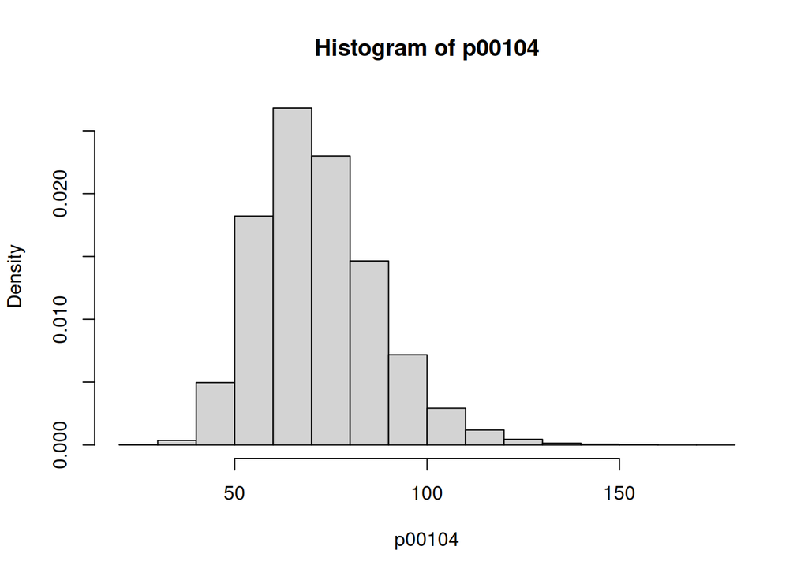

```r
svyhist(~p00104, pns_design_srvyr)
```

```r
sum(!is.na(pns_design_srvyr$variables$w00103))
```

```
## [1] 6730
```

```r
sum(!is.na(pns_design_srvyr$variables$w00203))
```

```
## [1] 6730
```

```r
#  mutate(diabetes2 = if_else(gender == "Female" & q03002 == "1" & q03001 == "1", 2,
#                       if_else(gender == "Female" & q03002 == "2" & q03001 == "1", 1,
#                         if_else(gender == "Male" & q03001 == "1", 1,
#                           if_else(gender == "Male" & q03001 == "2", 3,
#                             if_else(gender == "Female" & q03002 == "2" & q03001 == "2", 3, 4))))))
#                               if_else(q03001 == "9" | q03002 == "9" | is.na(q03001) | is.na(q03002), 4, 4)))))))
#pns_design_srvyr <- pns_design_srvyr %>%
#  mutate(diabetes = case_when(gender == "Female" & q03002 == 1 ~ 2, # Gravidez
#                              diabetes == 1 ~ 1, # Yes
#                              diabetes == 3 ~ 3, # No
#                              diabetes == 4 ~ 4, # Missing ou ignorado
#                              TRUE ~ diabetes))

round(svytable(~ diabetes, subset(pns_design_srvyr, c008>=18), addNA = TRUE, Ntotal = 100),4)
```

```
## diabetes
##       1       2       3       4
##  7.7232  0.3215 85.7097  6.2456
```

```r
# não vou transformar em fator .. não é necessário
#pns_design_srvyr$variables$diabetes <- ordered(pns_design_srvyr$variables$diabetes, levels = c(0, 1, 2, 3, 4), labels = c("Not Applicable","Yes","Pregnancy","No", "Missing"))

svytable(~q02901, subset(pns_design_srvyr, c008>=18), addNA = TRUE, Ntotal = 100)
```

```
## q02901
##         1         2         3         4         5         6
## 44.511457 19.712099 14.458868  5.270182  9.801804  6.245590
```

Os que nunca fizeram exame (q02901 == 6) estão como 4 em “diabetes”.

```r
svytable(~gender, subset(pns_design_srvyr, c008>=18), Ntotal = 100)
```

```
## gender
##   Female     Male
## 53.16198 46.83802
```

```r
table(pns_design_srvyr$variables$diabetes)
```

```
##
##     1     2     3     4
##  7101   273 76699  6773
```

```r
table(pns_design_srvyr$variables$q004p)
```

```
##
##   Sim   Não
##  7101 83745
```

```r
svytable(~q03002, subset(pns_design_srvyr, c008 >= 18), addNA = TRUE)
```

```
## q03002
##           1           2        <NA>
##    511698.7   7141173.5 151518438.9
```

```r
svytable(~q03001, subset(pns_design_srvyr, c008 >= 18 & gender == "Male"), addNA = TRUE)
```

```
## q03001
##        1        2     <NA>
##  5151966 62573983  6826749
```

```r
svytable(~q03001, subset(pns_design_srvyr, c008 >= 18 & gender == "Female"), addNA = TRUE)
```

```
## q03001
##        1        2     <NA>
##  7652872 73851302  3114439
```

```r
svytable(~q03001, subset(pns_design_srvyr, c008 >= 18 & gender == "Female" & q03002 == "2" & q03001 == "1"), addNA = TRUE)
```

```
## q03001
##       1       2    <NA>
## 7141173       0       0
```

```r
svytable(~q03001, subset(pns_design_srvyr, c008 >= 18 & gender == "Female" & q03002 == "1" & q03001 == "1"), addNA = TRUE)
```

```
## q03001
##        1        2     <NA>
## 511698.7      0.0      0.0
```

```r
svyby(~q03001, ~q03002, subset(pns_design_srvyr, c008 >= 18), svytotal, vartype = "ci", na.rm = TRUE)
```

```
##   q03002   q030011 q030012 ci_l.q030011 ci_l.q030012 ci_u.q030011 ci_u.q030012
## 1      1  511698.7       0     410997.9            0     612399.4            0
## 2      2 7141173.5       0    6810190.7            0    7472156.2            0
```

```r
svytable(~diabetes, subset(pns_design_srvyr, c008 >= 18), addNA = TRUE, Ntotal = 100)
```

```
## diabetes
##          1          2          3          4
##  7.7232133  0.3214767 85.7097201  6.2455899
```

```r
svytable(~q004p, subset(pns_design_srvyr, c008 >= 18), addNA = TRUE, Ntotal = 100)
```

```
## q004p
##       Sim       Não
##  7.723213 92.276787
```

```
Em 2019, a Pesquisa Nacional de Saúde estimou que no Brasil 7,7% da população de
18 anos ou mais de idade referiram diagnóstico médico de diabetes (em 2013, 6,2%), o
equivalente a um contingente de 12,3 milhões de pessoas
```

Para que o resultado esteja coerente com a PNS 2013 e com as publicações do IBGE/Fiocruz, é preciso filtrar a idade do morador para 18 anos ou mais. Publicação do IBGE (Volume 3 – Percepção do estado de saúde, estilos de vida, doenças crônicas e saúde bucal - https://www.pns.icict.fiocruz.br/wp-content/uploads/2021/02/liv101764.pdf) que indica 7.7% de pessoas com diabetes (pg. 59)

```r
svytable(~diabetes, subset(pns_design_srvyr, c008>=18), addNA = TRUE)
```

```
## diabetes
##           1           2           3           4
##  12293139.8    511698.7 136425285.1   9941187.4
```

Conferindo população total da pesquisa, maior de 18 anos.

```r
desPNSQ18=subset(pns_design_srvyr, c008>=18)
```

```r
todos <- svytable(~one, desPNSQ18)
todos
```

```
## one
##         1
## 159171311
```

```r
diabetes.df <- svyby(~one, ~diabetes, desPNSQ18, svytotal, vartype = "se", keep.names = F)
diabetes.df <- diabetes.df %>%
    mutate(diabetes = case_when(diabetes == 1 ~ "Yes",
                              diabetes == 2 ~ "Pregnancy",
                              diabetes == 3 ~ "No",
                              diabetes == 4 ~ "Never Tested"
                         )) %>%
   mutate(Perc = round(one/todos*100,2),PercSE = round(se/todos*100,2)) %>%
   rename(Diabetes=diabetes,Population=one,SE=se)
bind_rows(diabetes.df, tibble(Diabetes=NA, Population = round(sum(diabetes.df$Population),1), SE = NA, Perc = round(sum(diabetes.df$Perc),1), PercSE = NA)) %>% flextable() %>% autofit()
```

| Diabetes | Population | SE | Perc | PercSE |
| --- | --- | --- | --- | --- |
| Yes | 12.293.139,8 | 225.726,96 | 7,72 | 0,14 |
| Pregnancy | 511.698,7 | 51.378,87 | 0,32 | 0,03 |
| No | 136.425.285,1 | 319.629,77 | 85,71 | 0,20 |
| Never Tested | 9.941.187,4 | 239.034,08 | 6,25 | 0,15 |
|  | 159.171.311,0 |  | 100,00 |  |

```r
svyby( ~q004p , ~gender , desPNSQ18 , svymean,vartype= "ci") %>% flextable()
```

| gender | q004pSim | q004pNão | ci_l.q004pSim | ci_l.q004pNão | ci_u.q004pSim | ci_u.q004pNão |
| --- | --- | --- | --- | --- | --- | --- |
| Female | 0,08439247 | 0,9156075 | 0,08048100 | 0,9116961 | 0,08830393 | 0,9195190 |
| Male | 0,06910503 | 0,9308950 | 0,06488869 | 0,9266786 | 0,07332137 | 0,9351113 |

Esse resultado bate com a publicação do IBGE (op.cit), na página 60

```r
desPNSQ18 %>% select(q004p, gender) %>%
  tbl_strata(
    strata = gender,
    .tbl_fun =
      ~ .x %>%
      tbl_svysummary(by = q004p, percent = "row") %>%
      add_n(),
    .header = "**{strata}**, N = {n}"
  )
```

| **Characteristic** | **Female**, N = 84618613 **N** | **Female**, N = 84618613 **Sim**, N = 7,141,173<sup>1</sup> | **Female**, N = 84618613 **Não**, N = 77,477,439<sup>1</sup> | **Male**, N = 74552698 **N** | **Male**, N = 74552698 **Sim**, N = 5,151,966<sup>1</sup> | **Male**, N = 74552698 **Não**, N = 69,400,732<sup>1</sup> |
| --- | --- | --- | --- | --- | --- | --- |
| gender | 84,618,613 |  |  | 74,552,698 |  |  |
| Female |  | 7,141,173 (8.4%) | 77,477,439 (92%) |  | 0 (NA%) | 0 (NA%) |
| Male |  | 0 (NA%) | 0 (NA%) |  | 5,151,966 (6.9%) | 69,400,732 (93%) |

<sup>1</sup> n (%)

```r
desPNSQ18 %>%
  select(q004p,gender) %>%
  tbl_svysummary(by = q004p, percent = "row")
```

| **Characteristic** | **Sim**, N = 12,293,140<sup>1</sup> | **Não**, N = 146,878,171<sup>1</sup> |
| --- | --- | --- |
| gender |  |  |
| Female | 7,141,173 (8.4%) | 77,477,439 (92%) |
| Male | 5,151,966 (6.9%) | 69,400,732 (93%) |

<sup>1</sup> n (%)

```
As mulheres (8,4%) apresentaram maior proporção de relato de diagnóstico de
diabetes que os homens (6,9%).
```

```r
svytable(~diabetes, desPNSQ18, Ntotal = 100)
```

```
## diabetes
##          1          2          3          4
##  7.7232133  0.3214767 85.7097201  6.2455899
```

```r
svyby(~q004p,~gender, desPNSQ18, svymean, vartype = c("ci","se"))
```

```
##        gender   q004pSim  q004pNão se.q004pSim se.q004pNão ci_l.q004pSim
## Female Female 0.08439247 0.9156075 0.001995682 0.001995682    0.08048100
## Male     Male 0.06910503 0.9308950 0.002151231 0.002151231    0.06488869
##        ci_l.q004pNão ci_u.q004pSim ci_u.q004pNão
## Female     0.9116961    0.08830393     0.9195190
## Male       0.9266786    0.07332137     0.9351113
```

## Decisão sobre codificação da diabetes

Depois de quebrar a cabeça com a codificação correta da diabetes gestacional na PNS 2019, penso que será melhor simplesmente considerá-la como *não diabetes* nas estatísticas, assim como faz o IBGE. Pelos resultados que encontrei no livro do IBGE e no notebook da Fiocruz, a diabetes gestacional é considerada como não diabetes na estatística da PNS 2019.

Update: 20221021 O algoritmo de risco leva em conta se houve diabetes gestacional; se desconsiderar isso, não vou poder usar a variável `diabetes` para aplicar o algoritmo.

```r
pns_design_srvyr <- pns_design_srvyr %>%
  mutate(q03001 = as.character(q03001),
        q03002 = as.character(q03002)) %>%
  mutate(diabetes = case_when(gender == "Female" & q03002 == "1" ~ 2, # Gravidez -> No
                               q03001 == "1" ~ 1, #"Yes",
                               q03001 == "2" ~ 3, #"No",
                               q03001 == "9" ~ 4, #ignorado
                               TRUE ~ 4, #"Missing"
                               ))
```

Pegando novamente o subconjunto 18+ anos depois de recodificar a variável `diabetes`

```r
desPNSQ18=subset(pns_design_srvyr, c008>=18)
```

```r
svytable(~diabetes, desPNSQ18, addNA = TRUE, Ntotal = 100)
```

```
## diabetes
##          1          2          3          4
##  7.7232133  0.3214767 85.7097201  6.2455899
```

```r
comdiabetes19 <- svytable(~diabetes, desPNSQ18, addNA = TRUE)
comdiabetes19 <- as_tibble(comdiabetes19)
comdiabetes19 <- as.numeric(round(comdiabetes19[1,2], 0))
```

```r
svytable(~q02901, subset(pns_design_srvyr, c008>=18), addNA = TRUE, Ntotal = 100)
```

```
## q02901
##         1         2         3         4         5         6
## 44.511457 19.712099 14.458868  5.270182  9.801804  6.245590
```

O número de pessoas que nunca fizeram o exame de glicemia (q02901 == 6) bate com a codificação diabetes == 4.

### Homens

```r
svytable(~diabetes, subset(desPNSQ18, gender == "Male"), addNA = TRUE)
```

```
## diabetes
##        1        2        3        4
##  5151966        0 62573983  6826749
```

```r
svytable(~diabetes, subset(desPNSQ18, gender == "Male"), addNA = TRUE, Ntotal = 100)
```

```
## diabetes
##         1         2         3         4
##  6.910503  0.000000 83.932554  9.156944
```

### Mulheres

```r
svytable(~diabetes, subset(desPNSQ18, gender == "Female"), addNA = TRUE)
```

```
## diabetes
##          1          2          3          4
##  7141173.5   511698.7 73851301.7  3114438.9
```

```r
svytable(~diabetes, subset(desPNSQ18, gender == "Female"), addNA = TRUE, Ntotal = 100)
```

```
## diabetes
##          1          2          3          4
##  8.4392467  0.6047117 87.2754815  3.6805601
```

```r
table(pns_design_srvyr$variables$gender)
```

```
##
## Female   Male
##  48047  42799
```

Estes números batem com os apresentados pela Fiocruz no notebook R no site.

```r
todos <- svytable(~one, pns_design_srvyr)
todos
```

```
## one
##         1
## 168426190
```

```r
todos18 <- svytable(~one, desPNSQ18)
todos18
```

```
## one
##         1
## 159171311
```

```r
diabetes.df <- svyby(~one, ~diabetes, desPNSQ18, svytotal, vartype = c("se","ci"), keep.names = F)
diabetes.df <- diabetes.df %>%
   mutate(Perc = round(one/todos18*100,2),PercSE = round(se/todos18*100,2), Perci_l = round(ci_l/todos18*100,2), Perci_u = round(ci_u/todos18*100,2)) %>%
   rename(Diabetes=diabetes,Population=one,SE=se) %>%
  select(Diabetes, Population, Perc, PercSE, Perci_l, Perci_u)
bind_rows(diabetes.df, tibble(Population = round(sum(diabetes.df$Population),1),  Perc = round(sum(diabetes.df$Perc),1))) %>% flextable()
```

| Diabetes | Population | Perc | PercSE | Perci_l | Perci_u |
| --- | --- | --- | --- | --- | --- |
| 1 | 12.293.139,8 | 7,72 | 0,14 | 7,45 | 8,00 |
| 2 | 511.698,7 | 0,32 | 0,03 | 0,26 | 0,38 |
| 3 | 136.425.285,1 | 85,71 | 0,20 | 85,32 | 86,10 |
| 4 | 9.941.187,4 | 6,25 | 0,15 | 5,95 | 6,54 |
|  | 159.171.311,0 | 100,00 |  |  |  |

```r
round(svytable(~ diabetes, desPNSQ18, addNA = TRUE, Ntotal = 100), 2)
```

```
## diabetes
##     1     2     3     4
##  7.72  0.32 85.71  6.25
```

Apenas os que já tiveram diagnóstico de diabetes (Sim, Não, Gravidez)

```r
df_na <- desPNSQ18 %>%
  filter(diabetes != 4)
```

```r
com_diag <- svytable(~one, df_na)
com_diag
```

```
## one
##         1
## 149230124
```

```r
todos <- svytable(~one, desPNSQ18)
todos
```

```
## one
##         1
## 159171311
```

```r
todos - com_diag
```

```
## one
##       1
## 9941187
```

```r
#Separando a base de dados

#df = pns_design_srvyr[ ,c("c006", "c009", "fx_esc", "w00103", "w00203","p028", "p034", "p035", "p050", "q002", "q029", "q060", "q068", "q124", "fxetaria", "fxetaria2", "idade", "imc", "q030", "one", "uf","diabetes", "imcclass")]

#names(df$variables) = c("sexo_c006","cor_raca_c009", "faixa_escolaridade", "peso_w00103", "altura_w00203", "bebida_alcoolica_p028", "pratic_ativ_fisica_p034", "dias_semana_ativ_fisica_p035", "fumante_p050", "pressao_alta_q002", "exames_glicemia_q029", "colesterol_alto_q060", "avc_q068", "insuficiencia_renal_q124", "fxetaria", "fxetaria2", "idade", "imc", "diagnostico_diabetes_q030", "one", "uf","diabetes", "imcclass")

df <- select(desPNSQ18, sexo_c006=c006, cor_raca_c009 = c009, fx_esc,
             peso_w00103=w00103, altura_w00203=w00203, peso_p00104 = p00104,
             altura_p00404 = p00404, bebida_alcoolica_p028 = p02801,
             frutas_p018=p018, refri_sucos_p020=p02002,
             doces_p025=p02501, lanches_p026=p02602,
             pratic_ativ_fisica_p034 = p034, dias_semana_ativ_fisica_p035 = p035,
             fumante_p050 = p050, pressao_alta_q002 = q00201,
             exames_glicemia_q029 = q02901, colesterol_alto_q060 = q060,
             avc_q068 = q068, insuficiencia_renal_q124 = q124,
             fxetaria, fxetaria2, fxetaria3, idade, imc=imci,
             diagnostico_diabetes_q030 = q03001, one, uf, diabetes, regiao,
             imcclass=imcclassi, q03002, RaceSkinColor, Hypertension, gender, imcclass2, age)


#sexo_c006
#fumante_p050
#pressao_alta_q002
#colesterol_alto_q060
#avc_q068
#insuficiencia_renal_q124
# Consumo de Frutas (p018) -
#      Em quantos dias da semana o(a) Sr(a) costuma comer frutas?
#      (0 = Nunca ou menos de uma vez por semana)
# Refrigerante ou Suco de caixinha (p02002) -
#      Em quantos dias da semana o(a) Sr(a) costuma tomar refrigerante
#      (ou suco artificial)?
#      (0 = Nunca ou menos de uma vez por semana)
# Doces e Consumo de açúcar (p02501) -
#      Em quantos dias da semana o(a) Sr(a) come alimentos doces, tais como
#      pedaços de bolo ou torta, doces, chocolates, balas, biscoitos ou
#      bolachas doces? (0 = Nunca ou menos de uma vez por semana)
# Substitui refeição por lanches (p02602) -
#      Em quantos dias da semana o(a) Sr(a) substitui a refeição do almoço ou
#      jantar por sanduiches, salgados ou pizzas?
#      (0 = Nunca ou menos de uma vez por semana)

#df <- subset(df, !is.na(diabetes) & !is.na(pressao_alta_q002)  & !is.na(colesterol_alto_q060), !is.na(peso_w00103), !is.na(imc))
```

Total population for modeling

```r
svytable(~one, df)
```

```
## one
##         1
## 159171311
```

```r
df <- select(df, -diagnostico_diabetes_q030)
```

```r
verificacao <- as.data.frame(svytable(~ diabetes , df, addNA = TRUE, Ntotal = 1))
verificacao
```

[output not shown]

```r
sum(verificacao$Freq)
```

[output not shown]

```r
apply(df$variables, 2, function(x) sum(is.na(x)))
```

```
##                    sexo_c006                cor_raca_c009
##                            0                            0
##                       fx_esc                  peso_w00103
##                            0                        84116
##                altura_w00203                  peso_p00104
##                        84116                          892
##                altura_p00404        bebida_alcoolica_p028
##                          892                        66523
##                  frutas_p018             refri_sucos_p020
##                            0                            0
##                   doces_p025                 lanches_p026
##                            0                            0
##      pratic_ativ_fisica_p034 dias_semana_ativ_fisica_p035
##                            0                        54448
##                 fumante_p050            pressao_alta_q002
##                            0                         2110
##         exames_glicemia_q029         colesterol_alto_q060
##                            0                         7965
##                     avc_q068     insuficiencia_renal_q124
##                            0                            0
##                     fxetaria                    fxetaria2
##                            0                         2315
##                    fxetaria3                        idade
##                            0                            0
##                          imc                          one
##                          892                            0
##                           uf                     diabetes
##                            0                            0
##                       regiao                     imcclass
##                            0                            0
##                       q03002                RaceSkinColor
##                        86354                            0
##                 Hypertension                       gender
##                            0                            0
##                    imcclass2                          age
##                            0                            0
```

Perguntas da Avaliação de Risco: 1. What’s your age? 2. Are you a man or a woman? 3. If woman, have been diagnosed with gestational diabetes? 4. Any relative (mother, father, sister or brother) with diabetes? 5. High blood pressure diagnosis? 6. Physically active? 7. What is your weight status? Points based on height and weight ranges.

```r
sum(is.na(df$variables$dias_semana_ativ_fisica_p035))
```

```
## [1] 54448
```

```r
svytable(~ dias_semana_ativ_fisica_p035, df, addNA = TRUE)
```

```
## dias_semana_ativ_fisica_p035
##        0        1        2        3        4        5        6        7
##  2461827 10798638 12561811 15106053  5533732 11318045  2827419  6304128
##     <NA>
## 92259659
```

```r
svytable(~ pratic_ativ_fisica_p034, df, addNA = TRUE)
```

```
## pratic_ativ_fisica_p034
##        1        2
## 66911652 92259659
```

Na questão `p034`, o **1** significa que praticou atividade física nos últimos três meses; o **2** não praticou.

```r
svytable(~ dias_semana_ativ_fisica_p035 + pratic_ativ_fisica_p034, df, addNA = TRUE)
```

```
##                             pratic_ativ_fisica_p034
## dias_semana_ativ_fisica_p035        1        2
##                         0     2461827        0
##                         1    10798638        0
##                         2    12561811        0
##                         3    15106053        0
##                         4     5533732        0
##                         5    11318045        0
##                         6     2827419        0
##                         7     6304128        0
##                         <NA>        0 92259659
```

Juntando a informação da P034 e da P035 podemos ver que os `NAs` que aparecem na P035 podem ser considerados como *Não praticou atividade física*, ou seja, podemos atribuir 0 aos `NAs`.

```r
df <- df %>%
   mutate(ativ_fisica = as.integer(dias_semana_ativ_fisica_p035)) %>%
   mutate(ativ_fisica = case_when(ativ_fisica == 0 ~ 0,
                                  ativ_fisica == 1 ~ 1,
                                  ativ_fisica == 2 ~ 2,
                                  ativ_fisica == 3 ~ 3,
                                  ativ_fisica == 4 ~ 4,
                                  ativ_fisica == 5 ~ 5,
                                  ativ_fisica == 6 ~ 6,
                                  ativ_fisica == 7 ~ 7,
                                  TRUE ~ 0))
```

```r
svytable(~ ativ_fisica, df)
```

```
## ativ_fisica
##        0        1        2        3        4        5        6        7
## 94721486 10798638 12561811 15106053  5533732 11318045  2827419  6304128
```

Vou definir a variável `prat_ativ` como 0 para quem pratica atividade física menos de 3 vezes/semana e 1 para quem pratica três vezes ou mais na semana.

```r
df <- df %>%
   mutate(prat_ativ = case_when(ativ_fisica == 0 ~ 0, # Nenhuma vez
                     ativ_fisica == 1 ~ 0, # Uma vez/semana
                     ativ_fisica == 2 ~ 0, # Duas vezes/semana
                     ativ_fisica == 3 ~ 1, # Três vezes/semana
                     ativ_fisica == 4 ~ 1, # Quatro vezes/semana
                     ativ_fisica == 5 ~ 1, # Cinco vezes/semana
                     ativ_fisica == 6 ~ 1, # Seis vezes/semana
                     ativ_fisica == 7 ~ 1, # Sete vezes/semana
                     ))
```

## Risc Assessment Algorithm

```r
diab_tot <- as.data.frame(svytable(~ diabetes, df,  addNA = TRUE, Ntotal = 1))
diab_tot
```

```
##   diabetes        Freq
## 1        1 0.077232133
## 2        2 0.003214767
## 3        3 0.857097201
## 4        4 0.062455899
```

### Inspecting NAs

```r
apply(df$variables, 2, function(x) sum(is.na(x)))
```

```
##                    sexo_c006                cor_raca_c009
##                            0                            0
##                       fx_esc                  peso_w00103
##                            0                        84116
##                altura_w00203                  peso_p00104
##                        84116                          892
##                altura_p00404        bebida_alcoolica_p028
##                          892                        66523
##                  frutas_p018             refri_sucos_p020
##                            0                            0
##                   doces_p025                 lanches_p026
##                            0                            0
##      pratic_ativ_fisica_p034 dias_semana_ativ_fisica_p035
##                            0                        54448
##                 fumante_p050            pressao_alta_q002
##                            0                         2110
##         exames_glicemia_q029         colesterol_alto_q060
##                            0                         7965
##                     avc_q068     insuficiencia_renal_q124
##                            0                            0
##                     fxetaria                    fxetaria2
##                            0                         2315
##                    fxetaria3                        idade
##                            0                            0
##                          imc                          one
##                          892                            0
##                           uf                     diabetes
##                            0                            0
##                       regiao                     imcclass
##                            0                            0
##                       q03002                RaceSkinColor
##                        86354                            0
##                 Hypertension                       gender
##                            0                            0
##                    imcclass2                          age
##                            0                            0
##                  ativ_fisica                    prat_ativ
##                            0                            0
```

Dos resultados acima, podemos descartar algumas variáveis que não utilizaremos já que foram tratadas: `pratic_ativ_fisica_p034` e `dias_semana_ativ_fisica_p035`.

```r
df <- select(df, -pratic_ativ_fisica_p034, -dias_semana_ativ_fisica_p035)
```

```r
apply(df$variables, 2, function(x) sum(is.na(x)))
```

```
##                sexo_c006            cor_raca_c009                   fx_esc
##                        0                        0                        0
##              peso_w00103            altura_w00203              peso_p00104
##                    84116                    84116                      892
##            altura_p00404    bebida_alcoolica_p028              frutas_p018
##                      892                    66523                        0
##         refri_sucos_p020               doces_p025             lanches_p026
##                        0                        0                        0
##             fumante_p050        pressao_alta_q002     exames_glicemia_q029
##                        0                     2110                        0
##     colesterol_alto_q060                 avc_q068 insuficiencia_renal_q124
##                     7965                        0                        0
##                 fxetaria                fxetaria2                fxetaria3
##                        0                     2315                        0
##                    idade                      imc                      one
##                        0                      892                        0
##                       uf                 diabetes                   regiao
##                        0                        0                        0
##                 imcclass                   q03002            RaceSkinColor
##                        0                    86354                        0
##             Hypertension                   gender                imcclass2
##                        0                        0                        0
##                      age              ativ_fisica                prat_ativ
##                        0                        0                        0
```

```r
tlbpeso <- as.data.frame(svytable(~peso_p00104, df, addNA=TRUE))
tlbpeso
```

```
##     peso_p00104         Freq
## 1            25     846.9102
## 2            30    3955.7606
## 3            31     398.7019
## 4            32    3370.7981
## 5            33   21025.8511
## 6            34   29406.0085
## 7            35   25976.6117
## 8            36   17574.5154
## 9            37   64825.9549
## 10           38   76796.1566
## 11           39   51113.3663
## 12           40  204934.1950
## 13           41  119704.7999
## 14           42  333781.4837
```

[output cut: 117 more lines]

```r
sum(tlbpeso$Freq)
```

```
## [1] 159171311
```

```r
#df <- subset(df, !is.na(as.numeric(imc)))
```

```r
apply(df$variables, 2, function(x) sum(is.na(x)))
```

```
##                sexo_c006            cor_raca_c009                   fx_esc
##                        0                        0                        0
##              peso_w00103            altura_w00203              peso_p00104
##                    84116                    84116                      892
##            altura_p00404    bebida_alcoolica_p028              frutas_p018
##                      892                    66523                        0
##         refri_sucos_p020               doces_p025             lanches_p026
##                        0                        0                        0
##             fumante_p050        pressao_alta_q002     exames_glicemia_q029
##                        0                     2110                        0
##     colesterol_alto_q060                 avc_q068 insuficiencia_renal_q124
##                     7965                        0                        0
##                 fxetaria                fxetaria2                fxetaria3
##                        0                     2315                        0
##                    idade                      imc                      one
##                        0                      892                        0
##                       uf                 diabetes                   regiao
##                        0                        0                        0
##                 imcclass                   q03002            RaceSkinColor
##                        0                    86354                        0
##             Hypertension                   gender                imcclass2
##                        0                        0                        0
##                      age              ativ_fisica                prat_ativ
##                        0                        0                        0
```

Proporção de dados faltantes (peso e altura):

Por estados

```r
desPNSQ18 <- desPNSQ18 %>%
  mutate(faltapeso = case_when(is.na(p00104) ~ 1,
                               TRUE ~ 0),
         faltaalt = case_when(is.na(p00404) ~ 1,
                              TRUE ~ 0))
```

```r
# altura auto declarada
xalt <- as.data.frame.table(svytable(~uf + faltaalt, desPNSQ18, addNA = TRUE))
xalt2 <- left_join(filter(xalt,faltaalt == 1), filter(xalt, faltaalt == 0), by = "uf") %>%
  select(-faltaalt.x,-faltaalt.y,TemAlt=Freq.y,FaltaAlt=Freq.x) #%>%
xalt2 %>%  rowwise() %>%
  mutate(`% NA` = round(FaltaAlt/(TemAlt+FaltaAlt)*100,2)) %>%
  #select(-Falta,-Tem) %>%
  ungroup() %>%
  arrange(as.character(uf)) %>%
  flextable()
```

| uf | FaltaAlt | TemAlt | % NA |
| --- | --- | --- | --- |
| Acre | 8.634,858 | 582.990,9 | 1,46 |
| Alagoas | 28.917,548 | 2.373.486,5 | 1,20 |
| Amapa | 8.063,241 | 549.356,2 | 1,45 |
| Amazonas | 39.997,081 | 2.618.359,3 | 1,50 |
| Bahia | 110.655,002 | 11.043.951,8 | 0,99 |
| Ceara | 76.465,027 | 6.765.127,7 | 1,12 |
| Distrito Federal | 35.182,180 | 2.272.964,5 | 1,52 |
| Espirito Santo | 27.618,814 | 3.004.043,0 | 0,91 |
| Goias | 70.103,161 | 5.175.188,9 | 1,34 |
| Maranhao | 58.510,248 | 4.791.703,5 | 1,21 |
| Mato Grosso | 27.955,156 | 2.482.142,1 | 1,11 |
| Mato Grosso do Sul | 21.467,492 | 1.962.638,5 | 1,08 |
| Minas Gerais | 199.848,901 | 16.379.085,5 | 1,21 |
| Para | 78.870,261 | 5.876.412,5 | 1,32 |
| Paraiba | 32.883,739 | 2.954.803,8 | 1,10 |
| Parana | 73.267,431 | 8.726.101,0 | 0,83 |
| Pernambuco | 65.790,255 | 7.033.429,4 | 0,93 |
| Piaui | 22.951,668 | 2.425.553,3 | 0,94 |
| Rio Grande do Norte | 27.873,356 | 2.591.561,8 | 1,06 |
| Rio Grande do Sul | 89.502,927 | 8.842.401,4 | 1,00 |
| Rio de Janeiro | 83.781,316 | 13.631.527,1 | 0,61 |
| Rondonia | 19.465,915 | 1.235.880,9 | 1,55 |
| Roraima | 8.146,455 | 350.491,1 | 2,27 |
| Santa Catarina | 71.370,035 | 5.571.081,6 | 1,26 |
| Sao Paulo | 292.955,972 | 35.529.634,2 | 0,82 |
| Sergipe | 14.909,909 | 1.688.240,3 | 0,88 |
| Tocantins | 16.247,391 | 1.101.719,0 | 1,45 |

```r
# peso auto declarado
xpeso <- as.data.frame.table(svytable(~uf + faltapeso, desPNSQ18, addNA = TRUE))
xpeso2 <- left_join(filter(xpeso,faltapeso == 1), filter(xpeso, faltapeso == 0), by = "uf") %>%
  select(-faltapeso.x,-faltapeso.y,TemPeso=Freq.y,FaltaPeso=Freq.x) # %>%
xpeso2 %>%  rowwise() %>%
  mutate(`% NA` = round(FaltaPeso/(TemPeso+FaltaPeso)*100,2)) %>%
#  select(-Falta,-Tem) %>%
  ungroup() %>%
  arrange(as.character(uf)) %>%
  flextable()
```

| uf | FaltaPeso | TemPeso | % NA |
| --- | --- | --- | --- |
| Acre | 8.634,858 | 582.990,9 | 1,46 |
| Alagoas | 28.917,548 | 2.373.486,5 | 1,20 |
| Amapa | 8.063,241 | 549.356,2 | 1,45 |
| Amazonas | 39.997,081 | 2.618.359,3 | 1,50 |
| Bahia | 110.655,002 | 11.043.951,8 | 0,99 |
| Ceara | 76.465,027 | 6.765.127,7 | 1,12 |
| Distrito Federal | 35.182,180 | 2.272.964,5 | 1,52 |
| Espirito Santo | 27.618,814 | 3.004.043,0 | 0,91 |
| Goias | 70.103,161 | 5.175.188,9 | 1,34 |
| Maranhao | 58.510,248 | 4.791.703,5 | 1,21 |
| Mato Grosso | 27.955,156 | 2.482.142,1 | 1,11 |
| Mato Grosso do Sul | 21.467,492 | 1.962.638,5 | 1,08 |
| Minas Gerais | 199.848,901 | 16.379.085,5 | 1,21 |
| Para | 78.870,261 | 5.876.412,5 | 1,32 |
| Paraiba | 32.883,739 | 2.954.803,8 | 1,10 |
| Parana | 73.267,431 | 8.726.101,0 | 0,83 |
| Pernambuco | 65.790,255 | 7.033.429,4 | 0,93 |
| Piaui | 22.951,668 | 2.425.553,3 | 0,94 |
| Rio Grande do Norte | 27.873,356 | 2.591.561,8 | 1,06 |
| Rio Grande do Sul | 89.502,927 | 8.842.401,4 | 1,00 |
| Rio de Janeiro | 83.781,316 | 13.631.527,1 | 0,61 |
| Rondonia | 19.465,915 | 1.235.880,9 | 1,55 |
| Roraima | 8.146,455 | 350.491,1 | 2,27 |
| Santa Catarina | 71.370,035 | 5.571.081,6 | 1,26 |
| Sao Paulo | 292.955,972 | 35.529.634,2 | 0,82 |
| Sergipe | 14.909,909 | 1.688.240,3 | 0,88 |
| Tocantins | 16.247,391 | 1.101.719,0 | 1,45 |

Faltam as mesmas quantidades e nas mesmas observações.

```r
left_join(xalt2, xpeso2, by = "uf") %>%
  arrange(as.character(uf)) %>%
  flextable()
```

| uf | FaltaAlt | TemAlt | FaltaPeso | TemPeso |
| --- | --- | --- | --- | --- |
| Acre | 8.634,858 | 582.990,9 | 8.634,858 | 582.990,9 |
| Alagoas | 28.917,548 | 2.373.486,5 | 28.917,548 | 2.373.486,5 |
| Amapa | 8.063,241 | 549.356,2 | 8.063,241 | 549.356,2 |
| Amazonas | 39.997,081 | 2.618.359,3 | 39.997,081 | 2.618.359,3 |
| Bahia | 110.655,002 | 11.043.951,8 | 110.655,002 | 11.043.951,8 |
| Ceara | 76.465,027 | 6.765.127,7 | 76.465,027 | 6.765.127,7 |
| Distrito Federal | 35.182,180 | 2.272.964,5 | 35.182,180 | 2.272.964,5 |
| Espirito Santo | 27.618,814 | 3.004.043,0 | 27.618,814 | 3.004.043,0 |
| Goias | 70.103,161 | 5.175.188,9 | 70.103,161 | 5.175.188,9 |
| Maranhao | 58.510,248 | 4.791.703,5 | 58.510,248 | 4.791.703,5 |
| Mato Grosso | 27.955,156 | 2.482.142,1 | 27.955,156 | 2.482.142,1 |
| Mato Grosso do Sul | 21.467,492 | 1.962.638,5 | 21.467,492 | 1.962.638,5 |
| Minas Gerais | 199.848,901 | 16.379.085,5 | 199.848,901 | 16.379.085,5 |
| Para | 78.870,261 | 5.876.412,5 | 78.870,261 | 5.876.412,5 |
| Paraiba | 32.883,739 | 2.954.803,8 | 32.883,739 | 2.954.803,8 |
| Parana | 73.267,431 | 8.726.101,0 | 73.267,431 | 8.726.101,0 |
| Pernambuco | 65.790,255 | 7.033.429,4 | 65.790,255 | 7.033.429,4 |
| Piaui | 22.951,668 | 2.425.553,3 | 22.951,668 | 2.425.553,3 |
| Rio Grande do Norte | 27.873,356 | 2.591.561,8 | 27.873,356 | 2.591.561,8 |
| Rio Grande do Sul | 89.502,927 | 8.842.401,4 | 89.502,927 | 8.842.401,4 |
| Rio de Janeiro | 83.781,316 | 13.631.527,1 | 83.781,316 | 13.631.527,1 |
| Rondonia | 19.465,915 | 1.235.880,9 | 19.465,915 | 1.235.880,9 |
| Roraima | 8.146,455 | 350.491,1 | 8.146,455 | 350.491,1 |
| Santa Catarina | 71.370,035 | 5.571.081,6 | 71.370,035 | 5.571.081,6 |
| Sao Paulo | 292.955,972 | 35.529.634,2 | 292.955,972 | 35.529.634,2 |
| Sergipe | 14.909,909 | 1.688.240,3 | 14.909,909 | 1.688.240,3 |
| Tocantins | 16.247,391 | 1.101.719,0 | 16.247,391 | 1.101.719,0 |

Por Faixa Etária 2

```r
as.data.frame(round(svytable(~fxetaria2, subset(desPNSQ18, is.na(p00404)), addNA = TRUE, Ntotal = 100),2))
```

```
##   fxetaria2  Freq
## 1     18-24 32.44
## 2     25-34 41.90
## 3     35-44 22.15
## 4     45-54  2.86
## 5     55-64  0.24
## 6       65+  0.41
## 7      <NA>  0.00
```

```r
as.data.frame(round(svytable(~age, subset(desPNSQ18, is.na(p00404)), addNA = TRUE, Ntotal = 100),2))
```

```
##     age  Freq
## 1   <18  0.00
## 2 18-24 32.44
## 3 25-34 41.90
## 4 35-44 22.15
## 5 45-54  2.86
## 6 55-64  0.24
## 7   65+  0.41
```

Por IMC

```r
as.data.frame(round(svytable(~imcclass2, desPNSQ18, addNA = TRUE, Ntotal = 100),2))
```

```
##              imcclass2  Freq
## 1     Low/Normal (<25) 41.34
## 2 Overweight (25-29.9) 36.61
## 3        Obesity (>30) 21.03
## 4         Missing Data  1.01
```

```r
df_risco <- read_csv("ADAalgorithmRiskAssessmnt.csv",
    locale = locale(decimal_mark = ",")) %>% rename(altura=Altura)
df_risco_show = df_risco
df_risco_show = within(df_risco_show,  V1 <- paste(V1.inf, V1.sup, sep="-"))
df_risco_show = within(df_risco_show,  V2 <- paste(V2.inf, V2.sup, sep="-"))
df_risco_show = within(df_risco_show,  V3 <- paste(V3, "+",sep=""))
df_risco_show = df_risco_show[c("altura", "V1", "V2", "V3")]
df_risco_show
```

```
## # A tibble: 19 × 4
##    altura V1     V2      V3
##     <dbl> <chr>  <chr>   <chr>
##  1   1.47 54-64  65-86   87+
##  2   1.5  56-67  67-89   90+
##  3   1.52 58-69  69-92   93+
##  4   1.55 60-71  72-95   96+
##  5   1.57 62-74  74-98   99+
##  6   1.6  64-76  77-102  102+
##  7   1.63 66-78  79-105  105+
##  8   1.65 68-81  82-108  109+
##  9   1.68 70-84  84-112  112+
## 10   1.7  72-86  87-115  116+
## 11   1.73 74-89  89-118  119+
## 12   1.75 77-92  92-122  122+
## 13   1.78 79-94  95-126  126+
## 14   1.8  81-97  98-129  130+
## 15   1.83 83-100 100-133 133+
## 16   1.85 86-103 103-137 137+
## 17   1.88 88-105 106-141 141+
## 18   1.91 91-108 109-144 144+
## 19   1.93 93-111 112-148 149+
```

### Computing points

#### Altura

```r
df_risco$altura = df_risco$altura * 100
```

```r
pegar_altura_tab <- function(df){

    alt = as.numeric(df["altura_p00404"])

    if (is.na(alt)){
       #cat("Erro, altura NA\n")
       n_alt <- NA
       return(n_alt)
    }

    n_alt = 0
    for (alt_tab in df_risco$altura){
        if (alt <= alt_tab){
            n_alt = alt_tab
            break
        }
    }
    if (n_alt == 0){
        n_alt = 193
    }

   return(n_alt)
}
```

```r
df$variables$altura_tab <- apply(df$variables, 1, pegar_altura_tab)
```

```r
svytable(~altura_tab, df, addNA=TRUE)
```

```
## altura_tab
##        147        150        152        155        157        160        163
##  3226394.0  5997777.7  4152646.3 11258990.0  7135285.6 19342276.9 14529299.0
##        165        168        170        173        175        178        180
## 16212055.2 15349668.3 14125251.7 11477756.3  9902901.9  8929433.0  5602898.3
##        183        185        188        191        193       <NA>
##  3823726.2  2488349.8  2087938.4  1135598.5   781628.7  1611435.3
```

```r
round(svytable(~altura_p00404, df, addNA = TRUE), 1)
```

```
## altura_p00404
##        128        129        130        131        132        133        134
##      858.8      311.5    46125.7      551.8    12996.7    18141.2    11861.7
##        135        136        137        138        139        140        141
##    47610.6    16316.5    24809.5    39702.4    16888.9   371591.7    90825.0
##        142        143        144        145        146        147        148
##   179275.3   190775.9   220489.3   887343.1   396514.0   653404.4   812786.6
##        149        150        151        152        153        154        155
##  1040933.9  4144057.2  1493556.3  2659090.0  2844246.0  2589834.2  5824909.8
##        156        157        158        159        160        161        162
##  3774546.6  3360739.0  4422242.2  3567611.5 11352423.1  2827591.9  6273953.8
##        163        164        165        166        167        168        169
##  5427753.3  4642590.5 11569464.7  3342621.1  5205811.9  6801235.2  4066218.2
##        170        171        172        173        174        175        176
## 10059033.5  2598568.7  5164361.9  3714825.7  3100383.5  6802518.4  2980085.1
##        177        178        179        180        181        182        183
##  1949827.5  3999520.4  1549078.1  4053820.2  1097291.8  1544607.9  1181826.5
##        184        185        186        187        188        189        190
##   927655.9  1560693.9   778727.0   898862.0   410349.5   428079.6   629326.8
##        191        192        193        194        195        196        197
##    78192.0   222122.5   148344.9    37560.2    88976.1    62482.1    83737.9
##        198        199        200        201        202        204        206
##    49016.2    35568.4    40250.1     3775.7     4829.7     2459.4     2505.5
##       <NA>
##  1611435.3
```

Mesmo número de NAs.

#### Peso

```r
pegar_pontos_peso <- function(df){

    alt = as.numeric(df["altura_tab"])
    peso = as.numeric(df["peso_p00104"])

    if (!is.na(alt) & length(df_risco[df_risco$altura == alt, "altura"]) > 0){

        tab_risco = df_risco[df_risco$altura == alt, ]

        if((peso >= tab_risco["V1.inf"]) & (peso <= tab_risco["V1.sup"])){
            return(1)
        } else if((peso >= tab_risco["V2.inf"]) & (peso <= tab_risco["V2.sup"])){
            return(2)
        } else if((peso >= tab_risco["V3"])){
            return(3)
        } else{
            return(0)
        }

    } else{
       if (is.na(alt)) {
          return(NA)
       }
        return (0)
    }

}
```

```r
df$variables$pontos_alt_peso <- apply(df$variables, 1, pegar_pontos_peso)
```

```r
svytable(~pontos_alt_peso, df, addNA=TRUE)
```

```
## pontos_alt_peso
##        0        1        2        3     <NA>
## 64630931 60747238 30274613  1907093  1611435
```

```r
round(svytable(~peso_p00104, df, addNA=TRUE),1)
```

```
## peso_p00104
##        25        30        31        32        33        34        35        36
##     846.9    3955.8     398.7    3370.8   21025.9   29406.0   25976.6   17574.5
##        37        38        39        40        41        42        43        44
##   64826.0   76796.2   51113.4  204934.2  119704.8  333781.5  309178.7  293826.3
##        45        46        47        48        49        50        51        52
##  724914.4  486757.9  777675.3  907720.8 1004638.6 1764844.6 1102429.1 2030633.3
##        53        54        55        56        57        58        59        60
## 2071411.6 2334331.8 2793669.7 2672821.4 2492557.6 3650638.8 2348639.4 5217896.6
##        61        62        63        64        65        66        67        68
## 2251096.1 4793179.8 4132540.4 3995352.3 6078671.9 2965263.2 3612898.2 5091091.3
##        69        70        71        72        73        74        75        76
## 2977102.1 6630373.8 2290654.0 5072141.5 3180581.7 3649380.8 5314082.6 2897766.3
##        77        78        79        80        81        82        83        84
## 2290924.7 4730497.8 2380172.9 5563409.0 1604042.3 3547421.4 2569228.8 2606547.0
##        85        86        87        88        89        90        91        92
## 3200591.1 2275667.4 1765381.7 1666022.5 1700307.2 2989944.6  761418.2 1835479.1
##        93        94        95        96        97        98        99       100
## 1108550.2 1223751.8 1651879.1 1057355.7  782531.5 1493709.3  387122.5 1564412.9
##       101       102       103       104       105       106       107       108
##  337689.4  728759.4  527237.0  377209.8  970554.8  310514.5  231917.2  343768.6
##       109       110       111       112       113       114       115       116
##  163333.0  848056.3   79260.7  282170.5  203279.3   99382.7  489016.5   73655.5
##       117       118       119       120       121       122       123       124
##  122793.5  141064.1   48851.9  428808.2   27108.7   68569.8   95506.9   82348.7
##       125       126       127       128       129       130       131       132
##  117284.2   60798.6   37503.9   48132.3   33208.3  178207.2   13416.0   49224.4
##       133       134       135       136       137       138       139       140
##   16313.1    2458.9   45784.8   19238.3   16523.7    2422.8    6058.8   57520.3
##       141       142       143       144       145       146       147       148
##    2535.1    4493.5    6713.6     693.0   21388.7   15791.0    2216.0    3239.5
##       149       150       152       153       155       157       160       168
##    2508.2   37220.3   16681.5     564.5    5800.0     923.8   23369.2    2257.7
##       170       176      <NA>
##     410.2    1276.1 1611435.3
```

#### Idade

```r
df <- df %>%
     mutate(pontos_idade = case_when(idade < 40 ~ 0,
                                     idade <= 49 ~ 1,
                                     idade <= 59 ~ 2,
                                     idade >= 60 ~ 3,
                                     TRUE ~ 10))
```

```r
svytable(~pontos_idade, df, addNA = TRUE)
```

```
## pontos_idade
##        0        1        2        3
## 68591017 28930814 27250627 34398853
```

#### Sexo

```r
df <- df %>%
     mutate(pontos_sexo = case_when(sexo_c006 == "masculino" ~ 1,
                                    TRUE ~ 0))
```

#### Diabetes Gestacional

```r
df <- df %>%
     mutate(pontos_sgrav = case_when(diabetes == "2" ~ 1,
                                    TRUE ~ 0))
```

#### Hipertensão

```r
df <- df %>%
     mutate(pontos_hipertensao = case_when(pressao_alta_q002 == "1" ~ 1,
                               TRUE ~ 0))
```

```r
table(df$variables$prat_ativ)
```

```
##
##     0     1
## 68010 22836
```

#### Atividade Física

```r
df <- df %>%
     mutate(pontos_atv_fisica = case_when(prat_ativ == 1 ~ 0,
                               TRUE ~ 1))
```

```r
svytable(~pontos_alt_peso, df, addNA = TRUE)
```

```
## pontos_alt_peso
##        0        1        2        3     <NA>
## 64630931 60747238 30274613  1907093  1611435
```

```r
sum(svytable(~pontos_alt_peso, df, addNA = TRUE))
```

```
## [1] 159171311
```

#### Totalização Pontos

```r
df <- df %>%
     mutate(pontos = pontos_idade + pontos_sexo + pontos_sgrav + pontos_hipertensao + pontos_atv_fisica + pontos_alt_peso)
```

```r
df$pontos = as.numeric(df$pontos)
df <- df %>%
     mutate(risco = case_when(pontos >= 5 ~ 1,
                               pontos < 5 ~ 0))
```

Visualizando onde estão os NAs e como serão tratados nas discussões

Removendo NAs do risco e pontos

```r
teste <- as.data.frame(survey::svytable(~ risco + pontos, df, exclude = NULL, na.action = na.pass))
teste %>% filter(!is.na(risco) & !is.na(pontos))
```

```
##    risco pontos         Freq
## 1      0      0 8.637783e+06
## 2      1      0 0.000000e+00
## 3      0      1 3.125757e+07
## 4      1      1 0.000000e+00
## 5      0      2 2.968312e+07
## 6      1      2 0.000000e+00
## 7      0      3 2.778597e+07
## 8      1      3 0.000000e+00
## 9      0      4 2.426906e+07
## 10     1      4 0.000000e+00
## 11     0      5 0.000000e+00
## 12     1      5 2.026207e+07
## 13     0      6 0.000000e+00
## 14     1      6 1.141610e+07
## 15     0      7 0.000000e+00
## 16     1      7 3.972890e+06
## 17     0      8 0.000000e+00
## 18     1      8 2.743907e+05
## 19     0      9 0.000000e+00
## 20     1      9 9.287056e+02
```

Visualizando NAs em risco e/ou pontos

```r
teste %>% filter(is.na(risco),  is.na(pontos))
```

```
##   risco pontos    Freq
## 1  <NA>   <NA> 1611435
```

Ou seja, os mesmos 1.611.435 que estão faltando dados de peso e altura estão aqui como NAs em risco e pontos. Este número vai aparecer no final das análises.

Validação

```r
dim(df$variables[df$variables$pontos >= 5 & df$variables$risco == 0, c("pontos","risco") ])
```

```
## [1] 892   2
```

Número total de pessoas com risco aumentado para diabetes

```r
ptsr1 <- sum(teste[teste$risco == 1, "Freq"], na.rm = T)
ptsr1
```

```
## [1] 35926373
```

```r
ptsr0 <- sum(teste[teste$risco == 0, "Freq"], na.rm = T)
ptsr0
```

```
## [1] 121633503
```

```r
ptsNA <- sum(teste[is.na(teste$risco), "Freq"], na.rm = T)
ptsNA
```

```
## [1] 1611435
```

```r
ptstt <- sum(teste[,"Freq"], na.rm = T)
ptstt
```

```
## [1] 159171311
```

```r
round(ptstt - ptsNA - ptsr0 - ptsr1, 3)
```

```
## [1] 0
```

```r
pontos_gerais <- as.data.frame(survey::svytable(~ risco + pontos + diabetes, df, addNA = TRUE))
pontos_gerais
```

```
##     risco pontos diabetes         Freq
## 1       0      0        1 5.209276e+04
## 2       1      0        1 0.000000e+00
## 3    <NA>      0        1 0.000000e+00
## 4       0      1        1 2.856776e+05
## 5       1      1        1 0.000000e+00
## 6    <NA>      1        1 0.000000e+00
## 7       0      2        1 5.271109e+05
## 8       1      2        1 0.000000e+00
## 9    <NA>      2        1 0.000000e+00
## 10      0      3        1 1.188937e+06
## 11      1      3        1 0.000000e+00
## 12   <NA>      3        1 0.000000e+00
## 13      0      4        1 2.209856e+06
## 14      1      4        1 0.000000e+00
```

[output cut: 118 more lines]

```r
pontos_gerais$pontos = as.numeric(pontos_gerais$pontos)
pontos_gerais[pontos_gerais$pontos >= 5 & pontos_gerais$risco == 0,]
```

```
##       risco pontos diabetes        Freq
## 13        0      5        1  2209855.94
## NA     <NA>     NA     <NA>          NA
## 16        0      6        1        0.00
## NA.1   <NA>     NA     <NA>          NA
## 19        0      7        1        0.00
## NA.2   <NA>     NA     <NA>          NA
## 22        0      8        1        0.00
## NA.3   <NA>     NA     <NA>          NA
## 25        0      9        1        0.00
## NA.4   <NA>     NA     <NA>          NA
## 28        0     10        1        0.00
## NA.5   <NA>     NA     <NA>          NA
## NA.6   <NA>     NA     <NA>          NA
## NA.7   <NA>     NA     <NA>          NA
## 46        0      5        2    77313.53
## NA.8   <NA>     NA     <NA>          NA
## 49        0      6        2        0.00
## NA.9   <NA>     NA     <NA>          NA
## 52        0      7        2        0.00
## NA.10  <NA>     NA     <NA>          NA
## 55        0      8        2        0.00
## NA.11  <NA>     NA     <NA>          NA
## 58        0      9        2        0.00
## NA.12  <NA>     NA     <NA>          NA
## 61        0     10        2        0.00
## NA.13  <NA>     NA     <NA>          NA
## NA.14  <NA>     NA     <NA>          NA
## NA.15  <NA>     NA     <NA>          NA
## 79        0      5        3 20889858.67
## NA.16  <NA>     NA     <NA>          NA
## 82        0      6        3        0.00
## NA.17  <NA>     NA     <NA>          NA
## 85        0      7        3        0.00
## NA.18  <NA>     NA     <NA>          NA
## 88        0      8        3        0.00
## NA.19  <NA>     NA     <NA>          NA
## 91        0      9        3        0.00
## NA.20  <NA>     NA     <NA>          NA
## 94        0     10        3        0.00
## NA.21  <NA>     NA     <NA>          NA
## NA.22  <NA>     NA     <NA>          NA
## NA.23  <NA>     NA     <NA>          NA
## 112       0      5        4  1092030.41
## NA.24  <NA>     NA     <NA>          NA
## 115       0      6        4        0.00
## NA.25  <NA>     NA     <NA>          NA
## 118       0      7        4        0.00
## NA.26  <NA>     NA     <NA>          NA
## 121       0      8        4        0.00
## NA.27  <NA>     NA     <NA>          NA
## 124       0      9        4        0.00
## NA.28  <NA>     NA     <NA>          NA
## 127       0     10        4        0.00
## NA.29  <NA>     NA     <NA>          NA
## NA.30  <NA>     NA     <NA>          NA
## NA.31  <NA>     NA     <NA>          NA
```

essa conta aqui não tá fazendo muito sentido … preciso ver o q significa.

```r
pontos_gerais$pontos = as.numeric(pontos_gerais$pontos)
sum(pontos_gerais[pontos_gerais$pontos >= 5,]$Freq, na.rm =T)
```

[output not shown]

Mas aqui está correto: total de pessoas em risco de diabetes

```r
ptsgr1 <- sum(pontos_gerais[pontos_gerais$risco == 1, "Freq"], na.rm = T)
ptsgr1
```

```
## [1] 35926373
```

```r
ptsgr0 <- sum(pontos_gerais[pontos_gerais$risco == 0, "Freq"], na.rm = T)
ptsgr0
```

```
## [1] 121633503
```

```r
ptsgrNA <- sum(pontos_gerais[is.na(pontos_gerais$risco), "Freq"])
ptsgrNA
```

```
## [1] 1611435
```

```r
ptsgrFreq <- sum(pontos_gerais$Freq, na.rm = T)
ptsgrFreq
```

```
## [1] 159171311
```

```r
round(ptsgrFreq - ptsgr1 - ptsgr0 - ptsgrNA,3)
```

```
## [1] 0
```

Pontos dos não diabéticos + os sem exame

(1: diagnóstico de diabetes; 2: diabetes gestacional; 3: sem diagnóstico de diabetes; 4: não aplicável – sem exame)

```r
pontos_n_diab = pontos_gerais[pontos_gerais$diabetes != 1 & pontos_gerais$diabetes != 2 & !is.na(pontos_gerais$diabetes) & !is.na(pontos_gerais$risco),]
```

```r
qtd_n_diab = sum(pontos_n_diab$Freq, na.rm = T)
qtd_n_diab
```

```
## [1] 144815895
```

Quantidade de não diabéticos com exame e sem exame, com risco

```r
qtd_risco = sum(pontos_n_diab[pontos_n_diab$risco == 1 & !is.na(pontos_n_diab$risco), "Freq"], na.rm = T)
qtd_risco
```

```
## [1] 27684649
```

```r
qtd_risco / qtd_n_diab
```

```
## [1] 0.1911713
```

```r
sum(pontos_n_diab[pontos_n_diab$risco == 0 & !is.na(pontos_n_diab$risco), "Freq"], na.rm = T)
```

```
## [1] 117131245
```

Validando resultados acima (com exame sem diagnóstico e sem exames)

```r
pontos_n_diab <- as.data.frame(survey::svytable(~ risco, subset(df, diabetes != 1 & !is.na(risco)), addNA = TRUE))
pontos_n_diab
```

```
##   risco      Freq
## 1     0 117369828
## 2     1  27916466
## 3  <NA>         0
```

```r
sum(pontos_n_diab$Freq, na.rm = T)
```

```
## [1] 145286294
```

Total de Não diabéticos (com exame)

```r
pontos_n_diab_c_exame = pontos_gerais[pontos_gerais$diabetes == 3 & !is.na(pontos_gerais$risco) ,]
(qtd_n_diab_com_exame <- sum(pontos_n_diab_c_exame$Freq, na.rm = T))
```

```
## [1] 134947199
```

```r
pontos_gerais %>% filter(diabetes == 3 & !is.na(risco)) %>%
   group_by(diabetes, risco) %>%
   summarise(Freq = sum(Freq, na.rm = T), Perc = round(Freq/qtd_n_diab_com_exame*100,2))
```

```
## # A tibble: 2 × 4
## # Groups:   diabetes [1]
##   diabetes risco       Freq  Perc
##   <fct>    <fct>      <dbl> <dbl>
## 1 3        0     107954890.    80
## 2 3        1      26992309.    20
```

```r
x <- pontos_gerais %>%
  group_by(diabetes, is.na(risco)) %>%
   summarise(Freq = round(sum(Freq, na.rm = T),0)) %>%
   filter(`is.na(risco)` == TRUE) %>% select(-`is.na(risco)`)
x %>% adorn_totals() %>%
flextable() %>% theme_booktabs()
```

Distribuição dos NAs do risco

| diabetes | Freq |
| --- | --- |
| 1 | 19.558 |
| 2 | 41.299 |
| 3 | 1.478.086 |
| 4 | 72.492 |
| Total | 1.611.435 |

```r
saveRDS(x, file = "distribuicaoNAsrisco2019_20230505.rds", compress = TRUE)
```

Gênero (com exame sem diagnóstico e sem exame)

```r
pontos_genero <- as.data.frame(survey::svytable(~ risco + sexo_c006, subset(df, diabetes != 1 & !is.na(risco)), addNA = TRUE))
head(pontos_genero)
```

```
##   risco sexo_c006     Freq
## 1     0         1 57619240
## 2     1         1 11781492
## 3  <NA>         1        0
## 4     0         2 59750588
## 5     1         2 16134974
## 6  <NA>         2        0
```

```r
# masculino
sum(pontos_genero[pontos_genero$sexo_c006 == 1 & pontos_genero$risco == 1,"Freq"], na.rm =T)
```

```
## [1] 11781492
```

```r
# feminino
sum(pontos_genero[pontos_genero$sexo_c006 == 2 & pontos_genero$risco == 1,"Freq"], na.rm= T)
```

```
## [1] 16134974
```

```r
pontos_genero %>% filter(risco == 1 & !is.na(risco)) %>%
   group_by(sexo_c006) %>%
   summarise(freq = sum(Freq, na.rm = T), perc = round((Freq/qtd_risco)*100,1))
```

```
## # A tibble: 2 × 3
##   sexo_c006      freq  perc
##   <fct>         <dbl> <dbl>
## 1 1         11781492.  42.6
## 2 2         16134974.  58.3
```

```r
sum(pontos_genero$Freq, na.rm = T)
```

```
## [1] 145286294
```

```r
sum(pontos_genero[pontos_genero$risco == 1, ]$Freq, na.rm = T)
```

```
## [1] 27916466
```

Faixa Etária 1 (com exame sem diagnóstico e sem exame)

```r
pontos_fxetaria <- as.data.frame(survey::svytable(~ risco + fxetaria, subset(df, diabetes != 1 & !is.na(risco)), exclude = NULL, na.action = na.pass))
pontos_fxetaria
```

```
##    risco fxetaria         Freq
## 1      0        2        0.000
## 2      1        2        0.000
## 3   <NA>        2        0.000
## 4      0        7        0.000
## 5      1        7        0.000
## 6   <NA>        7        0.000
## 7      0       12        0.000
## 8      1       12        0.000
## 9   <NA>       12        0.000
## 10     0       18  6069823.841
## 11     1       18     1910.809
## 12  <NA>       18        0.000
## 13     0       22 15296110.981
## 14     1       22    21404.448
## 15  <NA>       22        0.000
## 16     0       32 44652461.599
## 17     1       32   225468.111
## 18  <NA>       32        0.000
## 19     0       50 42584284.322
## 20     1       50  8988235.503
## 21  <NA>       50        0.000
## 22     0       60  8767147.093
## 23     1       60 18679447.614
## 24  <NA>       60        0.000
```

```r
group_by(pontos_fxetaria[pontos_fxetaria$risco == 1,], fxetaria) %>% summarise(freq = sum(Freq, na.rm = T), perc = round((Freq/qtd_risco)*100,2))
```

```
## # A tibble: 16 × 3
## # Groups:   fxetaria [9]
##    fxetaria      freq  perc
##    <fct>        <dbl> <dbl>
##  1 2               0   0
##  2 7               0   0
##  3 12              0   0
##  4 18           1911.  0.01
##  5 22          21404.  0.08
##  6 32         225468.  0.81
##  7 50        8988236. 32.5
##  8 60       18679448. 67.5
##  9 <NA>            0  NA
## 10 <NA>            0  NA
## 11 <NA>            0  NA
## 12 <NA>            0  NA
## 13 <NA>            0  NA
## 14 <NA>            0  NA
## 15 <NA>            0  NA
## 16 <NA>            0  NA
```

```r
sum(pontos_fxetaria$Freq, na.rm = T)
```

```
## [1] 145286294
```

```r
sum(pontos_fxetaria[pontos_fxetaria$risco == 1, ]$Freq, na.rm = T)
```

```
## [1] 27916466
```

Faixa Etária 2 (com exame sem diagnóstico e sem exame)

```r
pontos_fxetaria2 <- as.data.frame(survey::svytable(~ risco + fxetaria2, subset(df, diabetes != 1 & !is.na(risco)), addNA = TRUE))
pontos_fxetaria2
```

```
##    risco fxetaria2        Freq
## 1      0     18-24 21365934.82
## 2      1     18-24    23315.26
## 3   <NA>     18-24        0.00
## 4      0     25-34 27746912.68
## 5      1     25-34   128942.53
## 6   <NA>     25-34        0.00
## 7      0     35-44 29837550.07
## 8      1     35-44  1022166.08
## 9   <NA>     35-44        0.00
## 10     0     45-54 21628283.77
## 11     1     45-54  4542324.39
## 12  <NA>     45-54        0.00
## 13     0     55-64 11044946.21
## 14     1     55-64  9368255.46
## 15  <NA>     55-64        0.00
## 16     0       65+  5746200.28
## 17     1       65+ 12831462.77
## 18  <NA>       65+        0.00
## 19     0      <NA>        0.00
## 20     1      <NA>        0.00
## 21  <NA>      <NA>        0.00
```

```r
group_by(pontos_fxetaria2[pontos_fxetaria2$risco == 1,], fxetaria2) %>% summarise(freq = sum(Freq, na.rm = T), perc = round((Freq/qtd_risco)*100,2))
```

```
## # A tibble: 14 × 3
## # Groups:   fxetaria2 [7]
##    fxetaria2      freq  perc
##    <fct>         <dbl> <dbl>
##  1 18-24        23315.  0.08
##  2 25-34       128943.  0.47
##  3 35-44      1022166.  3.69
##  4 45-54      4542324. 16.4
##  5 55-64      9368255. 33.8
##  6 65+       12831463. 46.4
##  7 <NA>             0  NA
##  8 <NA>             0  NA
##  9 <NA>             0  NA
## 10 <NA>             0  NA
## 11 <NA>             0  NA
## 12 <NA>             0  NA
## 13 <NA>             0   0
## 14 <NA>             0  NA
```

```r
sum(pontos_fxetaria2$Freq, na.rm = T)
```

```
## [1] 145286294
```

```r
sum(pontos_fxetaria2[pontos_fxetaria2$risco == 1, ]$Freq, na.rm = T)
```

```
## [1] 27916466
```

IMC (com exame sem diagnóstico e sem exame)

```r
pontos_imc <- as.data.frame(survey::svytable(~ risco + imcclass, subset(df, diabetes != 1 & !is.na(risco)), addNA = TRUE))
pontos_imc
```

```
##    risco imcclass       Freq
## 1      0        1   736446.3
## 2      1        1   147933.4
## 3   <NA>        1        0.0
## 4      0        2  2242194.6
## 5      1        2   156687.1
## 6   <NA>        2        0.0
## 7      0        3 55176666.8
## 8      1        3  4100693.1
## 9   <NA>        3        0.0
## 10     0        4 41798464.3
## 11     1        4 11655108.7
## 12  <NA>        4        0.0
## 13     0        5 13151303.4
## 14     1        5  8586233.3
## 15  <NA>        5        0.0
## 16     0        6  3659239.0
## 17     1        6  2224844.7
## 18  <NA>        6        0.0
## 19     0        7   605513.5
## 20     1        7  1044966.3
## 21  <NA>        7        0.0
## 22     0   Nenhum        0.0
## 23     1   Nenhum        0.0
## 24  <NA>   Nenhum        0.0
```

```r
risco_imc = pontos_imc[pontos_imc$risco==1, ]
risco_imc$Freq = round(risco_imc$Freq)
risco_imc
```

```
##      risco imcclass     Freq
## 2        1        1   147933
## NA    <NA>     <NA>       NA
## 5        1        2   156687
## NA.1  <NA>     <NA>       NA
## 8        1        3  4100693
## NA.2  <NA>     <NA>       NA
## 11       1        4 11655109
## NA.3  <NA>     <NA>       NA
## 14       1        5  8586233
## NA.4  <NA>     <NA>       NA
## 17       1        6  2224845
## NA.5  <NA>     <NA>       NA
## 20       1        7  1044966
## NA.6  <NA>     <NA>       NA
## 23       1   Nenhum        0
## NA.7  <NA>     <NA>       NA
```

```r
sum(pontos_imc$Freq, na.rm = T)
```

```
## [1] 145286294
```

```r
sum(pontos_imc[pontos_imc$risco == 1, ]$Freq, na.rm = T)
```

```
## [1] 27916466
```

```r
gp_imc = group_by(pontos_imc[pontos_imc$risco==1, ], imcclass) %>% summarise(freq = sum(Freq, na.rm = T), perc = round((freq/qtd_risco)*100,2))
gp_imc$freq = round(gp_imc$freq)
gp_imc
```

```
## # A tibble: 9 × 3
##   imcclass     freq  perc
##   <fct>       <dbl> <dbl>
## 1 1          147933  0.53
## 2 2          156687  0.57
## 3 3         4100693 14.8
## 4 4        11655109 42.1
## 5 5         8586233 31.0
## 6 6         2224845  8.04
## 7 7         1044966  3.77
## 8 Nenhum          0  0
## 9 <NA>            0  0
```

Por Estados

```r
pontos_est <- as.data.frame(survey::svytable(~ risco + uf, subset(df, diabetes != 1 & !is.na(risco)), addNA = TRUE))
pontos_est
```

```
##    risco                  uf        Freq
## 1      0            Rondonia   988926.02
## 2      1            Rondonia   180846.86
## 3   <NA>            Rondonia        0.00
## 4      0                Acre   476169.39
## 5      1                Acre    81528.56
## 6   <NA>                Acre        0.00
## 7      0            Amazonas  2129043.67
## 8      1            Amazonas   345013.58
## 9   <NA>            Amazonas        0.00
## 10     0             Roraima   287558.17
## 11     1             Roraima    45010.11
## 12  <NA>             Roraima        0.00
## 13     0                Para  4771135.81
## 14     1                Para   770731.37
```

[output cut: 67 more lines]

```r
risco_est = pontos_est %>%
   filter(risco==1) %>%
   mutate(Freq = round(Freq), perc = round(Freq/qtd_risco*100,1))
risco_est
```

```
##    risco                  uf    Freq perc
## 1      1            Rondonia  180847  0.7
## 2      1                Acre   81529  0.3
## 3      1            Amazonas  345014  1.2
## 4      1             Roraima   45010  0.2
## 5      1                Para  770731  2.8
## 6      1               Amapa   73439  0.3
## 7      1           Tocantins  186703  0.7
## 8      1            Maranhao  687836  2.5
## 9      1               Piaui  392490  1.4
## 10     1               Ceara 1011484  3.7
## 11     1 Rio Grande do Norte  355238  1.3
## 12     1             Paraiba  533096  1.9
## 13     1          Pernambuco 1202906  4.3
## 14     1             Alagoas  391612  1.4
## 15     1             Sergipe  255488  0.9
## 16     1               Bahia 1867557  6.7
## 17     1        Minas Gerais 3067491 11.1
## 18     1      Espirito Santo  528312  1.9
## 19     1      Rio de Janeiro 2893016 10.4
## 20     1           Sao Paulo 6446827 23.3
## 21     1              Parana 1634171  5.9
## 22     1      Santa Catarina 1135833  4.1
## 23     1   Rio Grande do Sul 1949759  7.0
## 24     1  Mato Grosso do Sul  366617  1.3
## 25     1         Mato Grosso  401673  1.5
## 26     1               Goias  843047  3.0
## 27     1    Distrito Federal  268741  1.0
```

Exame há mais de 3 anos

```r
pontos_3a <- as.data.frame(survey::svytable(~ risco, subset(df, diabetes != 1 & diabetes != 2 & diabetes != 4 & exames_glicemia_q029 == "5" & !is.na(risco)), addNA = TRUE))
pontos_3a
```

```
##   risco     Freq
## 1     0 13172895
## 2     1  2075265
## 3  <NA>        0
```

Sem exame

```r
svytable(~exames_glicemia_q029 + diabetes, df, exclude = NULL, na.action = na.pass)
```

```
##                     diabetes
## exames_glicemia_q029           1           2           3           4
##                    1  9399150.53   265143.50 61185175.42        0.00
##                    2  1758379.66   121646.93 29495979.57        0.00
##                    3   740679.02    64714.58 22208976.82        0.00
##                    4   139355.86    10447.35  8238814.25        0.00
##                    5   255574.78    49746.31 15296339.04        0.00
##                    6        0.00        0.00        0.00  9941187.40
```

```r
svytable(~q02901 + q03001, pns_design_srvyr, addNA = TRUE)
```

```
##       q03001
## q02901          1          2       <NA>
##      1  9716093.9 63270096.8        0.0
##      2  1884990.6 31162580.8        0.0
##      3   828932.7 24042135.2        0.0
##      4   149803.2  8879397.6        0.0
##      5   305321.1 16172942.1        0.0
##      6        0.0        0.0 12013895.5
```

Acho que não vou poder “remover” os NAs; é preferível deixá-los para não distorcer as análises; coisa chata esse `survey`!

```r
svytable(~diabetes, df)
```

```
## diabetes
##           1           2           3           4
##  12293139.8    511698.7 136425285.1   9941187.4
```

```r
pontos_0 <- as.data.frame(survey::svytable(~risco, subset(df, diabetes != "1" & exames_glicemia_q029 == "6"), exclude = NULL, na.action = na.pass))
pontos_0
```

```
##   risco      Freq
## 1     0 9176355.4
## 2     1  692340.2
## 3  <NA>   72491.8
```

Quantidade de pessoas que nunca fizeram exame de glicemia e estão em risco

```r
qtd_risco_sem_exame <- pontos_0[pontos_0$risco == 1 & !is.na(pontos_0$risco), "Freq"]
qtd_risco_sem_exame
```

```
## [1] 692340.2
```

Total de pessoas que nunca fizeram exame de glicemia

```r
sum(pontos_0$Freq)
```

```
## [1] 9941187
```

Por Faixa Etária 2, que nunca fizeram exame

```r
pontos_0_fxetaria <- as.data.frame(survey::svytable(~ risco + fxetaria2, subset(df, exames_glicemia_q029 == "6" & !is.na(risco)), addNA = TRUE))
pontos_0_fxetaria
```

```
##    risco fxetaria2        Freq
## 1      0     18-24 2876117.058
## 2      1     18-24       0.000
## 3   <NA>     18-24       0.000
## 4      0     25-34 2446470.373
## 5      1     25-34    6608.498
## 6   <NA>     25-34       0.000
## 7      0     35-44 2069278.047
## 8      1     35-44   21562.211
## 9   <NA>     35-44       0.000
## 10     0     45-54 1030168.718
## 11     1     45-54  133272.690
## 12  <NA>     45-54       0.000
## 13     0     55-64  491317.670
## 14     1     55-64  234518.469
## 15  <NA>     55-64       0.000
## 16     0       65+  263003.536
## 17     1       65+  296378.325
## 18  <NA>       65+       0.000
## 19     0      <NA>       0.000
## 20     1      <NA>       0.000
## 21  <NA>      <NA>       0.000
```

```r
sum(pontos_0_fxetaria$Freq)
```

```
## [1] 9868696
```

```r
sum(pontos_0_fxetaria[pontos_0_fxetaria$risco == 1,]$Freq, na.rm = T)
```

```
## [1] 692340.2
```

Por faixa etária, nunca fizeram exame, com risco aumentado

```r
gp0_fxetaria = pontos_0_fxetaria %>%
   filter(risco == 1 & !is.na(risco)) %>%
   group_by(fxetaria2) %>% summarise(freq = sum(Freq), Perc = round(Freq/qtd_risco_sem_exame*100,1))
gp0_fxetaria$freq = round(gp0_fxetaria$freq, 0)
gp0_fxetaria
```

```
## # A tibble: 7 × 3
##   fxetaria2   freq  Perc
##   <fct>      <dbl> <dbl>
## 1 18-24          0   0
## 2 25-34       6608   1
## 3 35-44      21562   3.1
## 4 45-54     133273  19.2
## 5 55-64     234518  33.9
## 6 65+       296378  42.8
## 7 <NA>           0   0
```

```r
sum(gp0_fxetaria$freq)
```

```
## [1] 692339
```

Por estado, nunca fizeram exame

```r
pontos_0_est <- as.data.frame(survey::svytable(~ risco + uf, subset(df, diabetes!="1" & exames_glicemia_q029 == "6" & !is.na(risco)), exclude = NULL, na.action = na.pass))
pontos_0_est
```

```
##    risco                  uf         Freq
## 1      0            Rondonia  143126.4954
## 2      1            Rondonia    8282.7789
## 3   <NA>            Rondonia       0.0000
## 4      0                Acre  106408.6403
## 5      1                Acre    7749.1551
## 6   <NA>                Acre       0.0000
## 7      0            Amazonas  285828.2668
## 8      1            Amazonas   14252.3831
## 9   <NA>            Amazonas       0.0000
## 10     0             Roraima   32879.9067
## 11     1             Roraima    2017.4562
## 12  <NA>             Roraima       0.0000
## 13     0                Para  649099.6184
## 14     1                Para   37178.3201
```

[output cut: 67 more lines]

Por estado, nunca fizeram exame, com risco aumentado

```r
risco_0_est = pontos_0_est %>%
   filter(risco==1 & !is.na(risco)) %>%
   mutate(Freq = round(Freq), perc = round(Freq/qtd_risco_sem_exame*100,1))
#risco_0_est$Freq = round(risco_0_est$Freq)
risco_0_est
```

```
##    risco                  uf  Freq perc
## 1      1            Rondonia  8283  1.2
## 2      1                Acre  7749  1.1
## 3      1            Amazonas 14252  2.1
## 4      1             Roraima  2017  0.3
## 5      1                Para 37178  5.4
## 6      1               Amapa   798  0.1
## 7      1           Tocantins  7031  1.0
## 8      1            Maranhao 38195  5.5
## 9      1               Piaui 11116  1.6
## 10     1               Ceara 53625  7.7
## 11     1 Rio Grande do Norte 17323  2.5
## 12     1             Paraiba 28031  4.0
## 13     1          Pernambuco 28207  4.1
## 14     1             Alagoas 19710  2.8
## 15     1             Sergipe  4614  0.7
## 16     1               Bahia 80174 11.6
## 17     1        Minas Gerais 64000  9.2
## 18     1      Espirito Santo 11612  1.7
## 19     1      Rio de Janeiro 46576  6.7
## 20     1           Sao Paulo 71865 10.4
## 21     1              Parana 32069  4.6
## 22     1      Santa Catarina 20727  3.0
## 23     1   Rio Grande do Sul 31504  4.6
## 24     1  Mato Grosso do Sul  8470  1.2
## 25     1         Mato Grosso 13008  1.9
## 26     1               Goias 23050  3.3
## 27     1    Distrito Federal 11155  1.6
```

```r
sum(pontos_0_est[pontos_0_est$risco == 1, "Freq"], na.rm = T)
```

```
## [1] 692340.2
```

**Nota: 24 de outubro de 2022**: o algoritmo de avaliação de risco pontua, para as mulheres, se teve diagnóstico de diabetes gestacional; assim, penso que não devo excluir as mulheres que tiveram essa avaliação das tabulações da população em risco, já que estaria removendo pessoas que podem estar em risco. Então vou refazer as tabulações, retirando apenas as pessoas que efetivamente tiveram diagnóstico positivo de diabetes.

O `subset` original era esse aqui:

```
subset(df, diabetes != 1 & diabetes != 2 & !is.na(risco))
```

vou substituir por esse aqui:

```
subset(df, diabetes != 1 & !is.na(risco))
```

### Risco de diabetes total e por gênero pessoas com diabetes gestacional (2), diagnóstico negativo (3) ou sem exames (4)

```r
pontos_genero2019 <- svyby(~one, ~risco + gender, subset(df, diabetes != 1 & !is.na(risco)), svytotal, vartype = "ci", Ntotal = 1, multicore = TRUE)
```

```r
pontos_total2019 <- svyby(~one, ~risco , subset(df, diabetes != 1 & !is.na(risco)), svytotal, vartype = "ci", Ntotal = 1, multicore = TRUE)
todos19 <- round(todos - comdiabetes19, 0)
todos19 <- unclass(todos19)
```

```r
pontos_total19.df <- pontos_total2019 %>%
  filter(risco == 1) %>%
  mutate(one = round(one,0),
         `(%)`=round(one/sum(todos19)*100,1),
         ci_l_perc = round(ci_l/sum(todos19)*100,1),
         ci_u_perc = round(ci_u/sum(todos19)*100,1)) %>%
  select(-risco, -ci_l, -ci_u) %>%
  mutate(`%95CI`=paste0(ci_l_perc,"-",ci_u_perc)) %>%
  select(-ci_l_perc,-ci_u_perc) %>%
  rename(N=one) %>%
  mutate("AtRisk"="Total") %>%
  select(AtRisk,N,`(%)`,`%95CI`)

pontos_total19.df %>%
  #adorn_totals() %>%
  flextable() %>% autofit()
```

PNS 2019 - Risco População Total - diabetes gestacional, diagnóstico negativo e Sem Exame

| AtRisk | N | (%) | %95CI |
| --- | --- | --- | --- |
| Total | 27.916.466 | 19 | 18.6-19.4 |

```r
pontos_genero19.df <- pontos_genero2019 %>%
  filter(risco == 1) %>%
  mutate(one = round(one,0),
         `(%)`=round(one/sum(one)*100,1),
         ci_l_perc = round(ci_l/sum(one)*100,1),
         ci_u_perc = round(ci_u/sum(one)*100,1)) %>%
  select(-risco, -ci_l, -ci_u) %>%
  mutate(`%95CI`=paste0(ci_l_perc,"-",ci_u_perc)) %>%
  select(-ci_l_perc,-ci_u_perc) %>%
  rename(N=one) #%>%
#  bind_rows(pontos_total19.df)

pontos_genero19.df %>%
  adorn_totals() %>%
  flextable() %>% autofit()
```

PNS 2019 - Risco por Gênero - diabetes gestacional, diagnóstico negativo e Sem Exame

| gender | N | (%) | %95CI |
| --- | --- | --- | --- |
| Female | 16.134.974 | 57,8 | 56.3-59.3 |
| Male | 11.781.492 | 42,2 | 40.7-43.7 |
| Total | 27.916.466 | 100,0 | - |

```r
pontos_fxeta2_2019 <- svyby(~one, ~risco + fxetaria2, subset(df, diabetes != 1 & !is.na(risco)), svytotal, vartype = "ci",  Ntotal = 100,multicore = TRUE)
pontos_fxeta2_2019.df <- pontos_fxeta2_2019 %>% filter(risco == 1) %>%
  mutate(one = round(one,0),
         `(%)`=round(one/sum(one)*100,1),
         ci_l_perc = round(ci_l/sum(one)*100,1),
         ci_u_perc = round(ci_u/sum(one)*100,1)) %>%
  select(-risco, -ci_l, -ci_u) %>%
  mutate(`%95CI`=paste0(ci_l_perc,"-",ci_u_perc)) %>%
  select(-ci_l_perc,-ci_u_perc) %>%
  rename(N=one)

pontos_fxeta2_2019.df %>%
  adorn_totals() %>%
  flextable() %>% autofit()
```

PNS 2019 - Risco por Faixa Etária - diabetes gestacional, diagnóstico negativo e Sem Exame

| fxetaria2 | N | (%) | %95CI |
| --- | --- | --- | --- |
| 18-24 | 23.315 | 0,1 | 0-0.1 |
| 25-34 | 128.943 | 0,5 | 0.2-0.7 |
| 35-44 | 1.022.166 | 3,7 | 3.1-4.2 |
| 45-54 | 4.542.324 | 16,3 | 15.1-17.4 |
| 55-64 | 9.368.255 | 33,6 | 32.1-35 |
| 65+ | 12.831.463 | 46,0 | 44.7-47.2 |
| Total | 27.916.466 | 100,2 | - |

## IMC (com diabetes gestacional (2), exame sem diagnóstico (3) e sem exame(4))

```r
pontos_imc_2019 <- svyby(~one, ~risco + imcclass2, subset(df, diabetes != 1 & !is.na(risco)), svytotal, vartype = "ci",  Ntotal = 100,multicore = TRUE)
pontos_imc_2019.df <- pontos_imc_2019 %>% filter(risco == 1) %>%
  mutate(one = round(one,0),
         `(%)`=round(one/sum(one)*100,1),
         ci_l_perc = round(ci_l/sum(one)*100,1),
         ci_u_perc = round(ci_u/sum(one)*100,1)) %>%
  select(-risco, -ci_l, -ci_u) %>%
  mutate(`%95CI`=paste0(ci_l_perc,"-",ci_u_perc)) %>%
  select(-ci_l_perc,-ci_u_perc) %>%
  rename(N=one)

pontos_imc_2019.df %>%
  adorn_totals() %>%
  flextable() %>% autofit()
```

PNS 2019 - Risco por IMC - diabetes gestacional, diagnóstico negativo e Sem Exame

| imcclass2 | N | (%) | %95CI |
| --- | --- | --- | --- |
| Low/Normal (<25) | 4.405.314 | 15,8 | 14.8-16.7 |
| Overweight (25-29.9) | 11.655.109 | 41,7 | 40.4-43.1 |
| Obesity (>30) | 11.856.044 | 42,5 | 40.6-44.3 |
| Total | 27.916.467 | 100,0 | - |

## Escolaridade (com diabetes gestacional (2), exame sem diagnóstico (3) e sem exame(4))

```r
pontos_fxesc_2019 <- svyby(~one, ~risco + fx_esc, subset(df, diabetes != 1 & !is.na(risco)), svytotal, vartype = "ci",  Ntotal = 100,multicore = TRUE)
pontos_fxesc_2019.df <- pontos_fxesc_2019 %>% filter(risco == 1) %>%
  mutate(one = round(one,0),
         `(%)`=round(one/sum(one)*100,1),
         ci_l_perc = round(ci_l/sum(one)*100,1),
         ci_u_perc = round(ci_u/sum(one)*100,1)) %>%
  select(-risco, -ci_l, -ci_u) %>%
  mutate(`%95CI`=paste0(ci_l_perc,"-",ci_u_perc)) %>%
  select(-ci_l_perc,-ci_u_perc) %>%
  rename(N=one)

pontos_fxesc_2019.df %>%
  adorn_totals() %>%
  flextable() %>% autofit()
```

PNS 2019 - Risco por Escolaridade - diabetes gestacional, diagnóstico negativo e Sem Exame

| fx_esc | N | (%) | %95CI |
| --- | --- | --- | --- |
| IncElem | 15.955.263 | 57,2 | 55.5-58.8 |
| CompElem | 3.267.909 | 11,7 | 10.6-12.8 |
| CompHiSc | 5.467.842 | 19,6 | 18.4-20.7 |
| CompHigher | 3.225.452 | 11,6 | 10.6-12.5 |
| Total | 27.916.466 | 100,1 | - |

## Raça, Cor da Pele (com diabetes gestacional (2), exame sem diagnóstico (3) e sem exame(4))

```r
pontos_race_2019 <- svyby(~one, ~risco + RaceSkinColor, subset(df, diabetes != 1 & !is.na(risco)), svytotal, vartype = "ci",  Ntotal = 100,multicore = TRUE)
pontos_race_2019.df <- pontos_race_2019 %>% filter(risco == 1) %>%
  mutate(one = round(one,0),
         `(%)`=round(one/sum(one)*100,1),
         ci_l_perc = round(ci_l/sum(one)*100,1),
         ci_u_perc = round(ci_u/sum(one)*100,1)) %>%
  select(-risco, -ci_l, -ci_u) %>%
  mutate(`%95CI`=paste0(ci_l_perc,"-",ci_u_perc)) %>%
  select(-ci_l_perc,-ci_u_perc) %>%
  rename(N=one)

pontos_race_2019.df %>%
  adorn_totals() %>%
  flextable() %>% autofit()
```

PNS 2019 - Risco por Raça, Cor da Pele - diabetes gestacional, diagnóstico negativo e Sem Exame

| RaceSkinColor | N | (%) | %95CI |
| --- | --- | --- | --- |
| White | 13.225.407 | 47,4 | 45.7-49 |
| Black | 3.203.772 | 11,5 | 10.6-12.3 |
| Mixed-race | 11.015.761 | 39,5 | 38-40.9 |
| Asian | 315.910 | 1,1 | 0.8-1.5 |
| Indigenous | 154.910 | 0,6 | 0.4-0.7 |
| Ignored | 706 | 0,0 | 0-0 |
| Total | 27.916.466 | 100,1 | - |

## Hipertensão (com diabetes gestacional (2), exame sem diagnóstico (3) e sem exame(4))

```r
pontos_hypert_2019 <- svyby(~one, ~risco + Hypertension, subset(df, diabetes != 1 & !is.na(risco)), svytotal, vartype = "ci",  Ntotal = 100,multicore = TRUE)
pontos_hypert_2019.df <- pontos_hypert_2019 %>% filter(risco == 1) %>%
  mutate(one = round(one,0),
         `(%)`=round(one/sum(one)*100,1),
         ci_l_perc = round(ci_l/sum(one)*100,1),
         ci_u_perc = round(ci_u/sum(one)*100,1)) %>%
  select(-risco, -ci_l, -ci_u) %>%
  mutate(`%95CI`=paste0(ci_l_perc,"-",ci_u_perc)) %>%
  select(-ci_l_perc,-ci_u_perc) %>%
  rename(N=one)

pontos_hypert_2019.df %>%
  adorn_totals() %>%
  flextable() %>% autofit()
```

PNS 2019 - Risco por Hipertensão - diabetes gestacional, diagnóstico negativo e Sem Exame

| Hypertension | N | (%) | %95CI |
| --- | --- | --- | --- |
| Yes | 20.197.173 | 72,3 | 70.4-74.3 |
| No | 7.719.293 | 27,7 | 26.5-28.9 |
| Total | 27.916.466 | 100,0 | - |

# PNS 2019 - Juntando tudo em um data.frame

```r
pontos_fxeta2_2019.df <- as_tibble(pontos_fxeta2_2019.df) %>%
  add_column(Classe = "Age(years)") %>%
  rename(Nome = fxetaria2, n2019 = N) %>%
  mutate(Nome = as.character(Nome))
pontos_race_2019.df <- as_tibble(pontos_race_2019.df) %>%
  add_column(Classe = "RaceSkinColor") %>%
  rename(Nome = RaceSkinColor, n2019 = N) %>%
  mutate(Nome = as.character(Nome))
pontos_fxesc_2019.df <- as_tibble(pontos_fxesc_2019.df) %>%
  add_column(Classe = "Education") %>%
  rename(Nome = fx_esc, n2019 = N) %>%
  mutate(Nome = as.character(Nome))
pontos_imc_2019.df <- as_tibble(pontos_imc_2019.df) %>%
  add_column(Classe = "Body mass index(kg/m²)") %>%
  rename(Nome = imcclass2, n2019 = N) %>%
  mutate(Nome = as.character(Nome))
pontos_hypert_2019.df <- as_tibble(pontos_hypert_2019.df) %>%
  add_column(Classe = "Hypertension") %>%
  rename(Nome = Hypertension, n2019 = N) %>%
  mutate(Nome = as.character(Nome))

pontos_2019.df <- bind_rows(pontos_fxeta2_2019.df,pontos_race_2019.df,pontos_fxesc_2019.df,pontos_imc_2019.df,pontos_hypert_2019.df)
```

```r
pontos_2019.df %>%
     gt(rowname_col = "Nome", groupname_col = "Classe") %>%
  sub_missing() %>%
  cols_label(
    n2019 = "N",
#    n2019 = "N",
#    "(%)" = "(%)",
#    `%95CI` = "%95CI",
#    "2019 (%)" = "(%)",
#    `2019 %95CI` = "95%CI"
  ) %>%
  tab_spanner(
    label = "Characteristic",
    columns = c(Classe)
  ) %>%
  tab_spanner(
    label = "2019",
    columns = c(n2019, `(%)`, `%95CI`)
  )
```

|  | 2019 N | 2019 (%) | 2019 %95CI |
| --- | --- | --- | --- |
| Age(years) |  |  |  |
| 18-24 | 23315 | 0.1 | 0-0.1 |
| 25-34 | 128943 | 0.5 | 0.2-0.7 |
| 35-44 | 1022166 | 3.7 | 3.1-4.2 |
| 45-54 | 4542324 | 16.3 | 15.1-17.4 |
| 55-64 | 9368255 | 33.6 | 32.1-35 |
| 65+ | 12831463 | 46.0 | 44.7-47.2 |
| RaceSkinColor |  |  |  |
| White | 13225407 | 47.4 | 45.7-49 |
| Black | 3203772 | 11.5 | 10.6-12.3 |
| Mixed-race | 11015761 | 39.5 | 38-40.9 |
| Asian | 315910 | 1.1 | 0.8-1.5 |
| Indigenous | 154910 | 0.6 | 0.4-0.7 |
| Ignored | 706 | 0.0 | 0-0 |
| Education |  |  |  |
| IncElem | 15955263 | 57.2 | 55.5-58.8 |
| CompElem | 3267909 | 11.7 | 10.6-12.8 |
| CompHiSc | 5467842 | 19.6 | 18.4-20.7 |
| CompHigher | 3225452 | 11.6 | 10.6-12.5 |
| Body mass index(kg/m²) |  |  |  |
| Low/Normal (<25) | 4405314 | 15.8 | 14.8-16.7 |
| Overweight (25-29.9) | 11655109 | 41.7 | 40.4-43.1 |
| Obesity (>30) | 11856044 | 42.5 | 40.6-44.3 |
| Hypertension |  |  |  |
| Yes | 20197173 | 72.3 | 70.4-74.3 |
| No | 7719293 | 27.7 | 26.5-28.9 |

```r
pop_ufpns2019 <- as.data.frame(svyby(~one, ~uf, subset(df, diabetes != 1 & !is.na(risco)), svytotal, multicore = TRUE))
pop_ufpns2019 <- pop_ufpns2019 %>%
  select(-se, popul=one)
pop_ufpns2019 %>%
  adorn_totals() %>%
  flextable() %>% autofit()
```

PNS 2019 - População de cada estado

| uf | popul |
| --- | --- |
| Rondonia | 1.169.772,9 |
| Acre | 557.698,0 |
| Amazonas | 2.474.057,3 |
| Roraima | 332.568,3 |
| Para | 5.541.867,2 |
| Amapa | 525.379,4 |
| Tocantins | 1.031.755,9 |
| Maranhao | 4.524.217,2 |
| Piaui | 2.260.060,3 |
| Ceara | 6.184.878,7 |
| Rio Grande do Norte | 2.362.246,4 |
| Paraiba | 2.730.461,7 |
| Pernambuco | 6.532.059,8 |
| Alagoas | 2.186.328,5 |
| Sergipe | 1.572.881,2 |
| Bahia | 10.293.887,6 |
| Minas Gerais | 15.059.634,7 |
| Espirito Santo | 2.798.319,3 |
| Rio de Janeiro | 12.356.560,2 |
| Sao Paulo | 32.460.652,1 |
| Parana | 8.050.688,3 |
| Santa Catarina | 5.184.566,4 |
| Rio Grande do Sul | 8.063.877,1 |
| Mato Grosso do Sul | 1.807.068,5 |
| Mato Grosso | 2.317.798,2 |
| Goias | 4.785.770,9 |
| Distrito Federal | 2.121.238,4 |
| Total | 145.286.294,3 |

```r
pop_regpns2019 <- as.data.frame(svyby(~one, ~regiao, subset(df, diabetes != 1 & !is.na(risco)), svytotal, multicore = TRUE)) %>%
select(-se, popul=one)
```

```r
pontos_uf_2019 <- svyby(~one, ~risco + uf, subset(df, diabetes != 1 & !is.na(risco)), svytotal, vartype = "ci",  Ntotal = 100,multicore = TRUE)
pontos_uf_2019.df <- pontos_uf_2019 %>%
  filter(risco == 1) %>% left_join(pop_ufpns2019, by = "uf") %>%
  mutate(one = round(one,0), popul = round(popul,0),
         `(%)`=round(one/popul*100,1),
         ci_l_perc = round(ci_l/popul*100,1),
         ci_u_perc = round(ci_u/popul*100,1)) %>%
  select(-risco, -ci_l, -ci_u) %>%
  mutate(`%95CI`=paste0(ci_l_perc,"-",ci_u_perc)) %>%
  select(-ci_l_perc,-ci_u_perc, -popul) %>%
  rename(N=one)

pontos_uf_2019.df %>% arrange(desc(`(%)`)) %>%
 # adorn_totals() %>%
  flextable() %>% autofit()
```

PNS 2019 - Risco por UF - diabetes gestacional, diagnóstico negativo e Sem Exame

| uf | N | (%) | %95CI |
| --- | --- | --- | --- |
| Rio Grande do Sul | 1.949.759 | 24,2 | 22.7-25.7 |
| Rio de Janeiro | 2.893.016 | 23,4 | 22.2-24.6 |
| Santa Catarina | 1.135.833 | 21,9 | 20.4-23.4 |
| Minas Gerais | 3.067.491 | 20,4 | 19-21.7 |
| Parana | 1.634.171 | 20,3 | 18.9-21.7 |
| Mato Grosso do Sul | 366.617 | 20,3 | 18.8-21.8 |
| Sao Paulo | 6.446.827 | 19,9 | 18.5-21.2 |
| Paraiba | 533.096 | 19,5 | 18-21.1 |
| Espirito Santo | 528.312 | 18,9 | 17.5-20.3 |
| Pernambuco | 1.202.906 | 18,4 | 17.2-19.6 |
| Tocantins | 186.703 | 18,1 | 16.1-20.1 |
| Bahia | 1.867.557 | 18,1 | 16.6-19.6 |
| Alagoas | 391.612 | 17,9 | 16.3-19.5 |
| Goias | 843.047 | 17,6 | 15.8-19.4 |
| Piaui | 392.490 | 17,4 | 15.7-19 |
| Mato Grosso | 401.673 | 17,3 | 15.7-19 |
| Ceara | 1.011.484 | 16,4 | 15.2-17.5 |
| Sergipe | 255.488 | 16,2 | 14.8-17.7 |
| Rondonia | 180.847 | 15,5 | 13.7-17.3 |
| Maranhao | 687.836 | 15,2 | 14.2-16.2 |
| Rio Grande do Norte | 355.238 | 15,0 | 13.7-16.3 |
| Acre | 81.529 | 14,6 | 13.2-16 |
| Amapa | 73.439 | 14,0 | 12-16 |
| Amazonas | 345.014 | 13,9 | 12.8-15.1 |
| Para | 770.731 | 13,9 | 12.9-14.9 |
| Roraima | 45.010 | 13,5 | 11.9-15.1 |
| Distrito Federal | 268.741 | 12,7 | 10.9-14.4 |

```r
pontos_reg_2019 <- svyby(~one, ~risco + regiao, subset(df, diabetes != 1 & !is.na(risco)), svytotal, vartype = "ci",  Ntotal = 100,multicore = TRUE)
pontos_reg_2019.df <- pontos_reg_2019 %>%
  filter(risco == 1) %>%  left_join(pop_regpns2019, by = "regiao") %>%
  mutate(one = round(one,0),
         `(%)`=round(one/popul*100,1),
         ci_l_perc = round(ci_l/popul*100,1),
         ci_u_perc = round(ci_u/popul*100,1)) %>%
  select(-risco, -ci_l, -ci_u, -popul) %>%
  mutate(`%95CI`=paste0(ci_l_perc,"-",ci_u_perc)) %>%
  select(-ci_l_perc,-ci_u_perc) %>%
  rename(N=one)

pontos_reg_2019.df %>% arrange(desc(`(%)`)) %>%
#  adorn_totals() %>%
  flextable() %>% autofit()
```

PNS 2019 - Risco por Região - diabetes gestacional, diagnóstico negativo e Sem Exame

| regiao | N | (%) | %95CI |
| --- | --- | --- | --- |
| Sul | 4.719.763 | 22,2 | 21.3-23 |
| Sudeste | 12.935.647 | 20,6 | 19.8-21.5 |
| Nordeste | 6.697.707 | 17,3 | 16.8-17.9 |
| Centro-Oeste | 1.880.078 | 17,0 | 16.1-18 |
| Norte | 1.683.272 | 14,5 | 13.9-15.1 |

```r
pontos_uf_2019.df <-  as_tibble(pontos_uf_2019.df) %>%
  add_column(Classe = "UF") %>%
  rename(Nome = uf, n2019 = N) %>%
  mutate(Nome = as.character(Nome))
pontos_reg_2019.df <- as_tibble(pontos_reg_2019.df) %>%
  add_column(Classe = "Região") %>%
  rename(Nome = regiao, n2019 = N) %>%
  mutate(Nome = as.character(Nome))
pontos_tot_2019.df <- as_tibble(pontos_total19.df) %>%
  add_column(Classe = "AtRisk") %>%
  rename(Nome = AtRisk, n2019 = N) %>%
  mutate(Nome = as.character(Nome))
```

```r
pontos_2019.df <- bind_rows(pontos_2019.df, pontos_uf_2019.df,
                            pontos_reg_2019.df, pontos_tot_2019.df)
```

```r
saveRDS(pontos_2019.df, file = "pontos_2019_20230505.rds", compress = TRUE)
```